# 진현지_2231162_MidTerm_Project

#### month2

"month" 별로 반품 개수 알아보기

```python
returned2_month = returned2_df.groupby("month").sum()
returned2_month2 = returned2_df.groupby("month").mean()
```

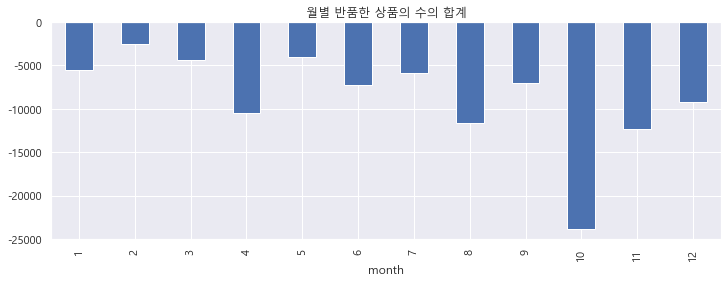

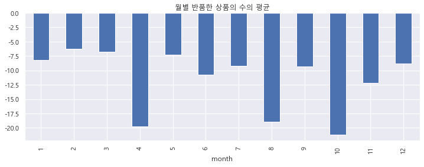

```python
plt.figure(figsize=(12,4))
returned2_month.Quantity.plot(kind = "bar");
plt.title('월별 반품한 상품의 수의 합계');

plt.figure(figsize=(12,4))
returned2_month2.Quantity.plot(kind = "bar");
plt.title('월별 반품한 상품의 수의 평균');
```

- 대체적으로 4월과 8월, 10월에 반품이 많은 것으로 확인됩니다.
- 개수의 총합은 8월 > 4월 이지만 평균은 8월 < 4월 입니다.

```python
returned2_df.month.value_counts()
```

```
10    1126
12    1044
11    1016
9      760
1      678
6      669
3      642
7      642
8      617
5      558
4      530
2      418
Name: month, dtype: int64
```

- 8월과 4월의 개수가 다른 것으로 확인됩니다.  
  그러나 8월의 평균 = -11662 / 617 이고  
  4월의 평균 = -10486 / 530 이므로  
  크게 유의미한 차이로 고려하지는 않아도 될듯 합니다.

"month" 별로 반품 상품의 금액 알아보기

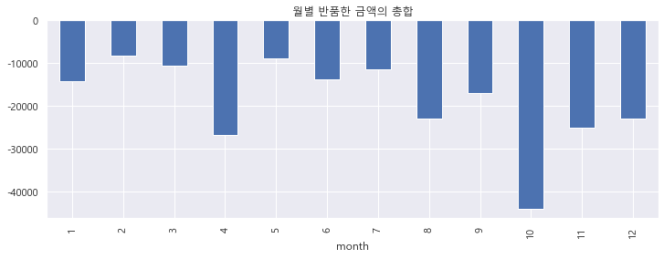

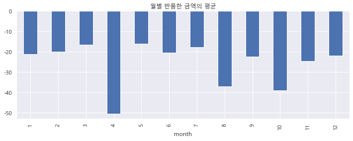

```python
plt.figure(figsize=(12,4))
returned2_month.TrAmount.plot(kind = "bar");
plt.title('월별 반품한 금액의 총합');

plt.figure(figsize=(12,4))
returned2_month2.TrAmount.plot(kind = "bar");
plt.title('월별 반품한 금액의 평균');
```

- 금액에서는 총합과 평균의 양상에 큰 차이가 없습니다.
- 첫 번째 분석과 다르게 1월, 12월의 반품 금액이 적은 것으로 나타나고  
  추가적으로 4, 8, 10월이 눈에 띄는 것으로 확인됩니다.

#### day2

"day" 별로 반품 개수 알아보기

```python
returned2_day = returned2_df.groupby("day").sum()
returned2_day2 = returned2_df.groupby("day").mean()
# dayofweek 월요일1 ~ 일요일7
```

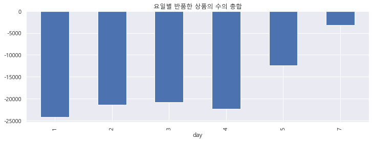

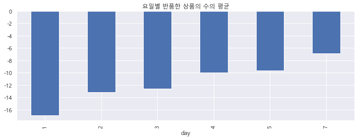

```python
plt.figure(figsize=(12,4))
returned2_day.Quantity.plot(kind = "bar");
plt.title('요일별 반품한 상품의 수의 총합');

plt.figure(figsize=(12,4))
returned2_day2.Quantity.plot(kind = "bar");
plt.title('요일별 반품한 상품의 수의 평균');
```

- 요일별 반품한 상품의 개수는 총합과 평균이 비슷한 양상을 보입니다.  
  그러나 총합에서는 목요일(4)에 반품된 수량이 많은 것으로 나타났지만, 평균에서는 목요일의 수량이 수요일보다 적은 것을 확인할 수 있습니다.  
  이 결과는 목요일의 개수가 다른 요일보다 현저히 많기 때문이라고 할 수 있습니다.  
  따라서 합계 차트를 참고하는 것이 좋겠습니다.
- 첫 번째 분석 결과와 같이 토요일(6)에는 반품량이 없는 것을 확인할 수 있고 일요일(7)의 반품량이 현저히 적은 것을 확인할 수 있습니다.  
  이는 위와 같이 CS 센터가 주말에는 운영을 안 한다는 것을 이유로 설명할 수 있을 것 같습니다.
- 주중에는 월요일(1)과 목요일에 반품량이 가장 많습니다.

```python
returned2_df.day.value_counts()
```

```
4    2247
3    1649
2    1630
1    1433
5    1289
7     452
Name: day, dtype: int64
```

"day" 별로 반품 상품의 금액 알아보기

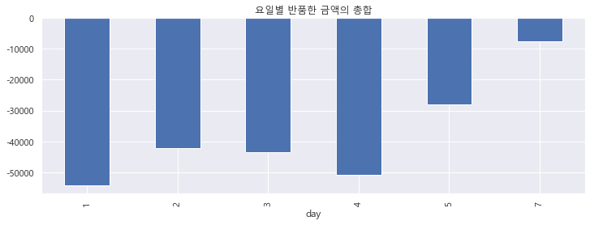

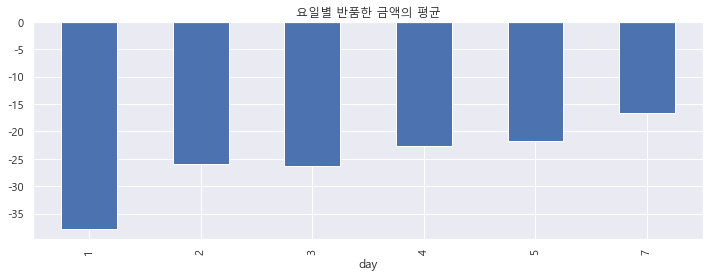

```python
plt.figure(figsize=(12,4))
returned2_day.TrAmount.plot(kind = "bar");
plt.title('요일별 반품한 금액의 총합');

plt.figure(figsize=(12,4))
returned2_day2.TrAmount.plot(kind = "bar");
plt.title('요일별 반품한 금액의 평균');
```

- 요일별 반품한 금액은 그 평균과 총합이 비슷한 양상을 보입니다.
- 또한, 수량과 금액의 그래프가 비슷한 양상을 가진다는 것을 알 수 있다.

#### hour2

"hour" 별로 반품 개수 알아보기

```python
returned2_hour = returned2_df.groupby("hour").sum()
returned2_hour2 = returned2_df.groupby("hour").mean()
```

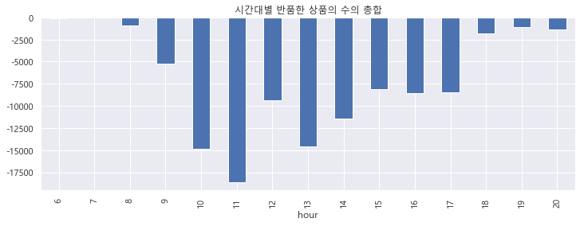

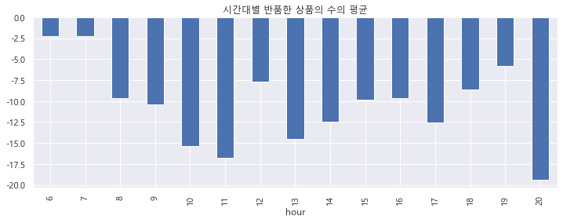

```python
plt.figure(figsize=(12,4))
returned2_hour.Quantity.plot(kind = "bar");
plt.title('시간대별 반품한 상품의 수의 총합');

plt.figure(figsize=(12,4))
returned2_hour2.Quantity.plot(kind = "bar");
plt.title('시간대별 반품한 상품의 수의 평균');
```

```python
returned2_df.hour.value_counts()
```

```
12    1215
11    1110
13    1003
10     963
14     918
16     887
15     825
17     679
9      501
18     206
19     184
8       99
20      68
6       38
7        4
Name: hour, dtype: int64
```

"hour" 별로 반품 상품의 금액 알아보기

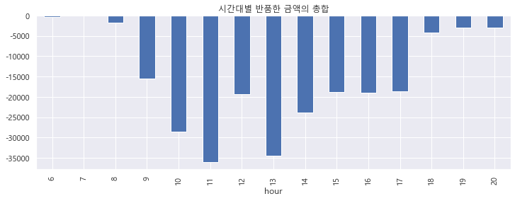

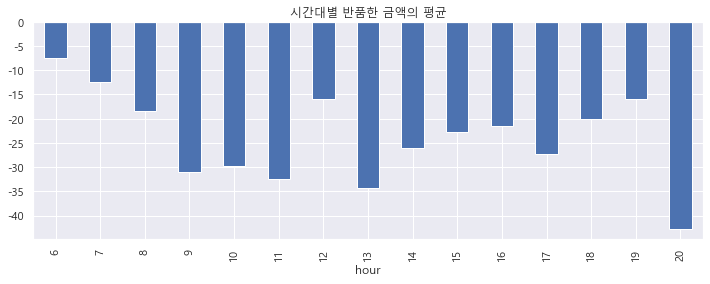

```python
plt.figure(figsize=(12,4))
returned2_hour.TrAmount.plot(kind = "bar");
plt.title('시간대별 반품한 금액의 총합');

plt.figure(figsize=(12,4))
returned2_hour2.TrAmount.plot(kind = "bar");
plt.title('시간대별 반품한 금액의 평균');
```

- 위의 상품의 수에서 설명한 것과 동일한 이유로 금액의 총합 그래프를 보고 분석하도록 하겠습니다.
- 수량 그래프와 마찬가지로 9시 ~ 17시에 데이터가 집중되어 있는 것을 볼 수 있습니다.
- 하지만 수량 그래프와 달리 13시에 반품한 금액의 합이 높게 나타난 것을 볼 수 있습니다.  
  이는 수량 대비 금액이 큰 것으로, 비교적 단가가 비싼 상품들이 주를 이룬다고 할 수 있습니다.

종합해보면

- 4월, 8월, 10월
- 월요일, 목요일
- 10~11시  
  에 반품되는 상품이 많다고 할 수 있습니다.

### 상품별 분석2

```python
returned2_product = returned2_df.groupby("Description").sum().sort_values(by = "Quantity")
returned2_product.head(10)
```

| Description | Quantity | UnitPrice | TrAmount | year_month | month | day | hour |
| --- | --- | --- | --- | --- | --- | --- | --- |
| PINK BLUE FELT CRAFT TRINKET BOX | -2617 | 5.87 | -2778.77 | 1005531 | 31 | 15 | 64 |
| WHITE HANGING HEART T-LIGHT HOLDER | -2578 | 117.90 | -6624.30 | 8445882 | 282 | 116 | 545 |
| GIN + TONIC DIET METAL SIGN | -2030 | 15.98 | -3775.33 | 1407651 | 51 | 18 | 97 |
| HERB MARKER BASIL | -1527 | 1.20 | -841.05 | 402213 | 13 | 5 | 22 |
| FELTCRAFT DOLL MOLLY | -1447 | 16.65 | -3512.65 | 1206557 | 57 | 19 | 75 |
| TEA TIME PARTY BUNTING | -1424 | 25.30 | -3692.95 | 1407734 | 34 | 20 | 82 |
| PAPER POCKET TRAVELING FAN | -1385 | 0.42 | -108.29 | 804435 | 35 | 13 | 58 |
| WORLD WAR 2 GLIDERS ASSTD DESIGNS | -1200 | 1.19 | -253.92 | 1005525 | 25 | 14 | 67 |
| COLOUR GLASS. STAR T-LIGHT HOLDER | -1174 | 76.58 | -3246.16 | 4826276 | 176 | 88 | 342 |
| JUMBO BAG RED RETROSPOT | -1115 | 84.01 | -1984.02 | 8848358 | 358 | 158 | 558 |

상품 중 가장 반품량이 많은 상품은

1. PINK BLUE FELT CRAFT TRINKET BOX
2. WHITE HANGING HEART T-LIGHT HOLDER
3. GIN + TONIC DIET METAL SIGN

입니다.

```python
returned2_product = returned2_df.groupby("Description").sum().sort_values(by = "TrAmount")
returned2_product.head(10)
```

| Description | Quantity | UnitPrice | TrAmount | year_month | month | day | hour |
| --- | --- | --- | --- | --- | --- | --- | --- |
| REGENCY CAKESTAND 3 TIER | -857 | 2169.15 | -9722.55 | 36398832 | 1032 | 569 | 2374 |
| WHITE HANGING HEART T-LIGHT HOLDER | -2578 | 117.90 | -6624.30 | 8445882 | 282 | 116 | 545 |
| PANTRY CHOPPING BOARD | -946 | 30.01 | -4803.06 | 1206660 | 60 | 21 | 80 |
| DOORMAT FAIRY CAKE | -674 | 22.95 | -4554.90 | 603317 | 17 | 8 | 40 |
| GIN + TONIC DIET METAL SIGN | -2030 | 15.98 | -3775.33 | 1407651 | 51 | 18 | 97 |
| TEA TIME PARTY BUNTING | -1424 | 25.30 | -3692.95 | 1407734 | 34 | 20 | 82 |
| FELTCRAFT DOLL MOLLY | -1447 | 16.65 | -3512.65 | 1206557 | 57 | 19 | 75 |
| COLOUR GLASS. STAR T-LIGHT HOLDER | -1174 | 76.58 | -3246.16 | 4826276 | 176 | 88 | 342 |
| PINK BLUE FELT CRAFT TRINKET BOX | -2617 | 5.87 | -2778.77 | 1005531 | 31 | 15 | 64 |
| IVORY DINER WALL CLOCK | -344 | 135.15 | -2653.70 | 3217608 | 108 | 58 | 240 |

한편, 가장 반품 상품의 총액이 높은 상품은

1. REGENCY CAKESTAND 3 TIER
2. WHITE HANGING HEART T-LIGHT HOLDER
3. PANTRY CHOPPING BOARD

입니다.

두 결과를 비교해보면 WHITE HANGING HEART T-LIGHT HOLDER 상품은 반품량도 많고 반품 상품의 총액도 높은 것을 확인할 수 있습니다.

[반품량 감소 방안]

WHITE HANGING HEART T-LIGHT HOLDER 상품도 위에서 설명했던 상품들과 유사하게 철제 제품으로 형태의 변형이 쉽습니다. 따라서 제조 및 배송 과정에 조금 더 신경써서 상품의 형태 변형(불량)을 줄이면 반품도 줄어들 것으로 보입니다.

[figure not shown]

WHITE HANGING HEART T-LIGHT HOLDR

```python
returned2_df.describe()
```

|  | Quantity | UnitPrice | TrAmount | year_month | month | day | hour |
| --- | --- | --- | --- | --- | --- | --- | --- |
| count | 8700.000000 | 8700.000000 | 8700.000000 | 8700.000000 | 8700.000000 | 8700.000000 | 8700.000000 |
| mean | -11.993793 | 4.415971 | -26.005837 | 201099.298621 | 7.310115 | 3.245632 | 13.165747 |
| std | 59.470348 | 9.117351 | 128.432042 | 25.967740 | 3.525339 | 1.571095 | 2.728278 |
| min | -2000.000000 | 0.060000 | -4921.500000 | 201012.000000 | 1.000000 | 1.000000 | 6.000000 |
| 25% | -6.000000 | 1.450000 | -16.600000 | 201103.000000 | 4.000000 | 2.000000 | 11.000000 |
| 50% | -2.000000 | 2.550000 | -8.400000 | 201107.000000 | 8.000000 | 3.000000 | 13.000000 |
| 75% | -1.000000 | 4.950000 | -3.300000 | 201110.000000 | 10.000000 | 4.000000 | 15.000000 |
| max | -1.000000 | 295.000000 | -0.120000 | 201112.000000 | 12.000000 | 7.000000 | 20.000000 |

```python
returned2_df.query("Description == 'WHITE HANGING HEART T-LIGHT HOLDER'")
```

|  | StockCode | InvoiceNo | Description | Quantity | InvoiceDate | UnitPrice | CustomerID | Country | TrAmount | InvoiceDatetime | year_month | month | day | hour |
| --- | --- | --- | --- | --- | --- | --- | --- | --- | --- | --- | --- | --- | --- | --- |
| 12321 | 85123A | C548972 | WHITE HANGING HEART T-LIGHT HOLDER | -6 | 2011-04-05 | 2.95 | 15674.0 | United Kingdom | -17.70 | 2011-04-05 11:42:00 | 201104 | 4 | 2 | 11 |
| 12359 | 85123A | C566471 | WHITE HANGING HEART T-LIGHT HOLDER | -1 | 2011-09-12 | 2.95 | 16670.0 | United Kingdom | -2.95 | 2011-09-12 18:18:00 | 201109 | 9 | 1 | 18 |
| 12393 | 85123A | C541415 | WHITE HANGING HEART T-LIGHT HOLDER | -1 | 2011-01-17 | 2.55 | 14292.0 | United Kingdom | -2.55 | 2011-01-17 16:20:00 | 201101 | 1 | 1 | 16 |
| 12434 | 85123A | C543791 | WHITE HANGING HEART T-LIGHT HOLDER | -1 | 2011-02-11 | 2.55 | 15270.0 | United Kingdom | -2.55 | 2011-02-11 17:13:00 | 201102 | 2 | 5 | 17 |
| 12451 | 85123A | C542910 | WHITE HANGING HEART T-LIGHT HOLDER | -1 | 2011-02-01 | 2.55 | 17511.0 | United Kingdom | -2.55 | 2011-02-01 15:38:00 | 201102 | 2 | 2 | 15 |
| 12504 | 85123A | C538834 | WHITE HANGING HEART T-LIGHT HOLDER | -1 | 2010-12-14 | 2.95 | 14415.0 | United Kingdom | -2.95 | 2010-12-14 13:06:00 | 201012 | 12 | 2 | 13 |
| 12523 | 85123A | C579752 | WHITE HANGING HEART T-LIGHT HOLDER | -1 | 2011-11-30 | 2.55 | 13777.0 | United Kingdom | -2.55 | 2011-11-30 14:46:00 | 201111 | 11 | 3 | 14 |
| 12629 | 85123A | C565237 | WHITE HANGING HEART T-LIGHT HOLDER | -8 | 2011-09-02 | 2.95 | 14299.0 | United Kingdom | -23.60 | 2011-09-02 09:47:00 | 201109 | 9 | 5 | 9 |
| 12745 | 85123A | C540244 | WHITE HANGING HEART T-LIGHT HOLDER | -1 | 2011-01-05 | 2.95 | 17213.0 | United Kingdom | -2.95 | 2011-01-05 15:40:00 | 201101 | 1 | 3 | 15 |
| 12929 | 85123A | C539329 | WHITE HANGING HEART T-LIGHT HOLDER | -500 | 2010-12-17 | 2.55 | 16013.0 | United Kingdom | -1275.00 | 2010-12-17 09:37:00 | 201012 | 12 | 5 | 9 |
| 13170 | 85123A | C550456 | WHITE HANGING HEART T-LIGHT HOLDER | -1930 | 2011-04-18 | 2.55 | 15749.0 | United Kingdom | -4921.50 | 2011-04-18 13:08:00 | 201104 | 4 | 1 | 13 |
| 13175 | 85123A | C580805 | WHITE HANGING HEART T-LIGHT HOLDER | -1 | 2011-12-06 | 2.95 | 16764.0 | United Kingdom | -2.95 | 2011-12-06 11:23:00 | 201112 | 12 | 2 | 11 |
| 13254 | 85123A | C562709 | WHITE HANGING HEART T-LIGHT HOLDER | -1 | 2011-08-08 | 2.55 | 17511.0 | United Kingdom | -2.55 | 2011-08-08 14:32:00 | 201108 | 8 | 1 | 14 |
| 13357 | 85123A | C567767 | WHITE HANGING HEART T-LIGHT HOLDER | -12 | 2011-09-22 | 2.95 | 17460.0 | United Kingdom | -35.40 | 2011-09-22 10:58:00 | 201109 | 9 | 4 | 10 |
| 13360 | 85123A | C542424 | WHITE HANGING HEART T-LIGHT HOLDER | -3 | 2011-01-28 | 2.95 | 18075.0 | United Kingdom | -8.85 | 2011-01-28 09:18:00 | 201101 | 1 | 5 | 9 |
| 13375 | 85123A | C541885 | WHITE HANGING HEART T-LIGHT HOLDER | -1 | 2011-01-24 | 2.95 | 16782.0 | United Kingdom | -2.95 | 2011-01-24 11:14:00 | 201101 | 1 | 1 | 11 |
| 13472 | 85123A | C539576 | WHITE HANGING HEART T-LIGHT HOLDER | -24 | 2010-12-20 | 2.95 | 14911.0 | EIRE | -70.80 | 2010-12-20 12:25:00 | 201012 | 12 | 1 | 12 |
| 13574 | 85123A | C538350 | WHITE HANGING HEART T-LIGHT HOLDER | -1 | 2010-12-10 | 2.55 | 13798.0 | United Kingdom | -2.55 | 2010-12-10 15:01:00 | 201012 | 12 | 5 | 15 |
| 13599 | 85123A | C562124 | WHITE HANGING HEART T-LIGHT HOLDER | -3 | 2011-08-02 | 2.55 | 13081.0 | United Kingdom | -7.65 | 2011-08-02 17:23:00 | 201108 | 8 | 2 | 17 |
| 13644 | 85123A | C577547 | WHITE HANGING HEART T-LIGHT HOLDER | -1 | 2011-11-20 | 2.95 | 17841.0 | United Kingdom | -2.95 | 2011-11-20 14:48:00 | 201111 | 11 | 7 | 14 |
| 13652 | 85123A | C539832 | WHITE HANGING HEART T-LIGHT HOLDER | -1 | 2010-12-22 | 2.55 | 17239.0 | United Kingdom | -2.55 | 2010-12-22 13:20:00 | 201012 | 12 | 3 | 13 |
| 13676 | 85123A | C563553 | WHITE HANGING HEART T-LIGHT HOLDER | -1 | 2011-08-17 | 2.95 | 16755.0 | United Kingdom | -2.95 | 2011-08-17 13:14:00 | 201108 | 8 | 3 | 13 |
| 13781 | 85123A | C542792 | WHITE HANGING HEART T-LIGHT HOLDER | -1 | 2011-02-01 | 2.95 | 14627.0 | United Kingdom | -2.95 | 2011-02-01 10:49:00 | 201102 | 2 | 2 | 10 |
| 13789 | 85123A | C576216 | WHITE HANGING HEART T-LIGHT HOLDER | -3 | 2011-11-14 | 2.95 | 12584.0 | Italy | -8.85 | 2011-11-14 12:56:00 | 201111 | 11 | 1 | 12 |
| 13816 | 85123A | C559486 | WHITE HANGING HEART T-LIGHT HOLDER | -1 | 2011-07-08 | 2.95 | 13047.0 | United Kingdom | -2.95 | 2011-07-08 13:51:00 | 201107 | 7 | 5 | 13 |
| 13861 | 85123A | C576243 | WHITE HANGING HEART T-LIGHT HOLDER | -1 | 2011-11-14 | 2.55 | 15953.0 | United Kingdom | -2.55 | 2011-11-14 13:38:00 | 201111 | 11 | 1 | 13 |
| 13914 | 85123A | C560409 | WHITE HANGING HEART T-LIGHT HOLDER | -6 | 2011-07-18 | 2.95 | 16717.0 | United Kingdom | -17.70 | 2011-07-18 14:24:00 | 201107 | 7 | 1 | 14 |
| 13917 | 85123A | C541710 | WHITE HANGING HEART T-LIGHT HOLDER | -3 | 2011-01-21 | 2.95 | 14320.0 | United Kingdom | -8.85 | 2011-01-21 11:17:00 | 201101 | 1 | 5 | 11 |
| 13932 | 85123A | C562961 | WHITE HANGING HEART T-LIGHT HOLDER | -6 | 2011-08-11 | 2.95 | 14305.0 | United Kingdom | -17.70 | 2011-08-11 10:24:00 | 201108 | 8 | 4 | 10 |
| 14047 | 85123A | C552849 | WHITE HANGING HEART T-LIGHT HOLDER | -12 | 2011-05-11 | 2.95 | 14367.0 | United Kingdom | -35.40 | 2011-05-11 14:52:00 | 201105 | 5 | 3 | 14 |
| 14076 | 85123A | C567348 | WHITE HANGING HEART T-LIGHT HOLDER | -1 | 2011-09-19 | 2.95 | 15755.0 | United Kingdom | -2.95 | 2011-09-19 15:57:00 | 201109 | 9 | 1 | 15 |
| 14122 | 85123A | C569548 | WHITE HANGING HEART T-LIGHT HOLDER | -1 | 2011-10-04 | 2.95 | 18053.0 | United Kingdom | -2.95 | 2011-10-04 17:31:00 | 201110 | 10 | 2 | 17 |
| 14194 | 85123A | C556293 | WHITE HANGING HEART T-LIGHT HOLDER | -18 | 2011-06-10 | 2.95 | 13094.0 | United Kingdom | -53.10 | 2011-06-10 09:30:00 | 201106 | 6 | 5 | 9 |
| 14234 | 85123A | C554333 | WHITE HANGING HEART T-LIGHT HOLDER | -3 | 2011-05-23 | 2.95 | 13310.0 | United Kingdom | -8.85 | 2011-05-23 17:15:00 | 201105 | 5 | 1 | 17 |
| 14256 | 85123A | C545852 | WHITE HANGING HEART T-LIGHT HOLDER | -8 | 2011-03-07 | 2.95 | 14048.0 | United Kingdom | -23.60 | 2011-03-07 13:49:00 | 201103 | 3 | 1 | 13 |
| 14354 | 85123A | C548513 | WHITE HANGING HEART T-LIGHT HOLDER | -8 | 2011-03-31 | 2.55 | 13777.0 | United Kingdom | -20.40 | 2011-03-31 15:54:00 | 201103 | 3 | 4 | 15 |
| 14512 | 85123A | C556888 | WHITE HANGING HEART T-LIGHT HOLDER | -1 | 2011-06-15 | 2.95 | 15005.0 | United Kingdom | -2.95 | 2011-06-15 12:37:00 | 201106 | 6 | 3 | 12 |
| 14525 | 85123A | C537602 | WHITE HANGING HEART T-LIGHT HOLDER | -1 | 2010-12-07 | 2.55 | 17511.0 | United Kingdom | -2.55 | 2010-12-07 12:45:00 | 201012 | 12 | 2 | 12 |
| 14542 | 85123A | C540403 | WHITE HANGING HEART T-LIGHT HOLDER | -1 | 2011-01-07 | 2.55 | 17230.0 | United Kingdom | -2.55 | 2011-01-07 09:32:00 | 201101 | 1 | 5 | 9 |
| 14575 | 85123A | C546519 | WHITE HANGING HEART T-LIGHT HOLDER | -1 | 2011-03-14 | 2.95 | 14350.0 | United Kingdom | -2.95 | 2011-03-14 12:27:00 | 201103 | 3 | 1 | 12 |
| 14581 | 85123A | C571856 | WHITE HANGING HEART T-LIGHT HOLDER | -1 | 2011-10-19 | 2.95 | 17063.0 | United Kingdom | -2.95 | 2011-10-19 13:37:00 | 201110 | 10 | 3 | 13 |
| 14590 | 85123A | C540837 | WHITE HANGING HEART T-LIGHT HOLDER | -1 | 2011-01-11 | 2.55 | 14733.0 | United Kingdom | -2.55 | 2011-01-11 15:02:00 | 201101 | 1 | 2 | 15 |

```python
returned2_df.query("Description == 'REGENCY CAKESTAND 3 TIER'")
```

|  | StockCode | InvoiceNo | Description | Quantity | InvoiceDate | UnitPrice | CustomerID | Country | TrAmount | InvoiceDatetime | year_month | month | day | hour |
| --- | --- | --- | --- | --- | --- | --- | --- | --- | --- | --- | --- | --- | --- | --- |
| 318315 | 22423 | C549666 | REGENCY CAKESTAND 3 TIER | -1 | 2011-04-11 | 10.95 | 13113.0 | United Kingdom | -10.95 | 2011-04-11 12:17:00 | 201104 | 4 | 1 | 12 |
| 318322 | 22423 | C544080 | REGENCY CAKESTAND 3 TIER | -4 | 2011-02-15 | 10.95 | 17819.0 | United Kingdom | -43.80 | 2011-02-15 15:46:00 | 201102 | 2 | 2 | 15 |
| 318361 | 22423 | C559502 | REGENCY CAKESTAND 3 TIER | -1 | 2011-07-08 | 12.75 | 13338.0 | United Kingdom | -12.75 | 2011-07-08 14:53:00 | 201107 | 7 | 5 | 14 |
| 318386 | 22423 | C556635 | REGENCY CAKESTAND 3 TIER | -1 | 2011-06-13 | 12.75 | 13505.0 | Switzerland | -12.75 | 2011-06-13 15:25:00 | 201106 | 6 | 1 | 15 |
| 318394 | 22423 | C567940 | REGENCY CAKESTAND 3 TIER | -1 | 2011-09-22 | 12.75 | 16984.0 | United Kingdom | -12.75 | 2011-09-22 18:21:00 | 201109 | 9 | 4 | 18 |
| ... | ... | ... | ... | ... | ... | ... | ... | ... | ... | ... | ... | ... | ... | ... |
| 320432 | 22423 | C552856 | REGENCY CAKESTAND 3 TIER | -1 | 2011-05-11 | 12.75 | 14288.0 | United Kingdom | -12.75 | 2011-05-11 15:17:00 | 201105 | 5 | 3 | 15 |
| 320436 | 22423 | C579192 | REGENCY CAKESTAND 3 TIER | -10 | 2011-11-28 | 12.75 | 12657.0 | France | -127.50 | 2011-11-28 15:43:00 | 201111 | 11 | 1 | 15 |
| 320449 | 22423 | C549908 | REGENCY CAKESTAND 3 TIER | -3 | 2011-04-12 | 10.95 | 13324.0 | United Kingdom | -32.85 | 2011-04-12 16:39:00 | 201104 | 4 | 2 | 16 |
| 320498 | 22423 | C569038 | REGENCY CAKESTAND 3 TIER | -1 | 2011-09-30 | 12.75 | 12940.0 | United Kingdom | -12.75 | 2011-09-30 10:46:00 | 201109 | 9 | 5 | 10 |
| 320504 | 22423 | C543607 | REGENCY CAKESTAND 3 TIER | -1 | 2011-02-10 | 12.75 | 15602.0 | United Kingdom | -12.75 | 2011-02-10 14:13:00 | 201102 | 2 | 4 | 14 |

181 rows × 14 columns

```python
returned2_df.query("Description == 'PANTRY CHOPPING BOARD'")
```

|  | StockCode | InvoiceNo | Description | Quantity | InvoiceDate | UnitPrice | CustomerID | Country | TrAmount | InvoiceDatetime | year_month | month | day | hour |
| --- | --- | --- | --- | --- | --- | --- | --- | --- | --- | --- | --- | --- | --- | --- |
| 171441 | 23113 | C575665 | PANTRY CHOPPING BOARD | -1 | 2011-11-10 | 4.95 | 17442.0 | United Kingdom | -4.95 | 2011-11-10 14:54:00 | 201111 | 11 | 4 | 14 |
| 171444 | 23113 | C579877 | PANTRY CHOPPING BOARD | -1 | 2011-11-30 | 4.95 | 16240.0 | United Kingdom | -4.95 | 2011-11-30 17:07:00 | 201111 | 11 | 3 | 17 |
| 171447 | 23113 | C574493 | PANTRY CHOPPING BOARD | -1 | 2011-11-04 | 4.95 | 14842.0 | United Kingdom | -4.95 | 2011-11-04 13:09:00 | 201111 | 11 | 5 | 13 |
| 171451 | 23113 | C568832 | PANTRY CHOPPING BOARD | -186 | 2011-09-29 | 5.15 | 17450.0 | United Kingdom | -957.90 | 2011-09-29 11:35:00 | 201109 | 9 | 4 | 11 |
| 171454 | 23113 | C568560 | PANTRY CHOPPING BOARD | -1 | 2011-09-27 | 4.95 | 14299.0 | United Kingdom | -4.95 | 2011-09-27 16:39:00 | 201109 | 9 | 2 | 16 |
| 171456 | 23113 | C567527 | PANTRY CHOPPING BOARD | -756 | 2011-09-21 | 5.06 | 17450.0 | United Kingdom | -3825.36 | 2011-09-21 09:16:00 | 201109 | 9 | 3 | 9 |

- WHITE HANGING HEART T-LIGHT HOLDER 상품의 Unitprice는 중위수(2.55)에 가까운 가격(2.95)인데 반품 상품의 총액에서 높은 순위를 차지했다는 것은 그 수량이 압도적으로 많은 것이라는 것을 알 수 있습니다.
- 실제로 비교를 해보면 Unitprice가 같이 순위에 든 REGENCY CAKESTAND 3 TIER(약 12.75)와 PANTRY CHOPPING BOARD(약 5.15)보다 훨씬 낮다는 것을 알 수 있습니다.

```python
returned2_product2 = returned2_df.groupby("Description").mean().sort_values(by = "Quantity")
returned2_product2.head(10)
```

| Description | Quantity | UnitPrice | TrAmount | year_month | month | day | hour |
| --- | --- | --- | --- | --- | --- | --- | --- |
| HERB MARKER BASIL | -763.50 | 0.600000 | -420.525000 | 201106.50 | 6.500000 | 2.500000 | 11.000000 |
| MIRROR MOSAIC T-LIGHT HOLDER | -720.00 | 0.390000 | -280.800000 | 201110.00 | 10.000000 | 1.000000 | 10.000000 |
| VINTAGE BILLBOARD TEA MUG | -701.00 | 1.060000 | -743.060000 | 201108.00 | 8.000000 | 3.000000 | 15.000000 |
| PINK BLUE FELT CRAFT TRINKET BOX | -523.40 | 1.174000 | -555.754000 | 201106.20 | 6.200000 | 3.000000 | 12.800000 |
| BASKET OF TOADSTOOLS | -408.00 | 1.060000 | -432.480000 | 201107.00 | 7.000000 | 4.000000 | 17.000000 |
| PAPER POCKET TRAVELING FAN | -346.25 | 0.105000 | -27.072500 | 201108.75 | 8.750000 | 3.250000 | 14.500000 |
| MIRROR MOSAIC VOTIVE HOLDER | -324.00 | 0.390000 | -126.360000 | 201110.00 | 10.000000 | 1.000000 | 10.000000 |
| GOLD MINI TAPE MEASURE | -300.00 | 0.720000 | -216.000000 | 201012.00 | 12.000000 | 5.000000 | 9.000000 |
| GIN + TONIC DIET METAL SIGN | -290.00 | 2.282857 | -539.332857 | 201093.00 | 7.285714 | 2.571429 | 13.857143 |
| BOYS ALPHABET IRON ON PATCHES | -288.00 | 0.210000 | -60.480000 | 201111.00 | 11.000000 | 1.000000 | 10.000000 |

```python
returned2_df.Description.value_counts()
```

```
REGENCY CAKESTAND 3 TIER               181
JAM MAKING SET WITH JARS                87
SET OF 3 CAKE TINS PANTRY DESIGN        74
STRAWBERRY CERAMIC TRINKET BOX          55
ROSES REGENCY TEACUP AND SAUCER         54
                                      ...
DIAMANTE HEART SHAPED WALL MIRROR,       1
MEDIUM PARLOUR PICTURE FRAME             1
HEART DECORATION RUSTIC HANGING          1
SWEETHEART BIRD HOUSE                    1
JET BLACK LAS VEGAS NECKLACE 45CM        1
Name: Description, Length: 1962, dtype: int64
```

### 나라별 분석

이상치를 제거한 returned2_df 로 분석을 진행하겠습니다.

```python
returned2_df.Country.value_counts()
```

```
United Kingdom        7359
Germany                437
EIRE                   292
France                 134
USA                    112
Australia               73
Spain                   45
Italy                   42
Belgium                 36
Japan                   34
Switzerland             33
Malta                   14
Portugal                11
Norway                  11
Poland                  11
Channel Islands          9
Sweden                   9
Denmark                  8
Cyprus                   7
Finland                  6
Czech Republic           4
Netherlands              4
Austria                  3
Israel                   2
European Community       1
Bahrain                  1
Saudi Arabia             1
Hong Kong                1
Name: Country, dtype: int64
```

```python
returned2_country = returned2_df.groupby("Country").sum().sort_values(by = "Quantity")
returned2_country
```

| Country | Quantity | UnitPrice | TrAmount | year_month | month | day | hour |
| --- | --- | --- | --- | --- | --- | --- | --- |
| United Kingdom | -90415 | 33074.64 | -193369.98 | 1479888152 | 53252 | 24284 | 97148 |
| EIRE | -4800 | 1280.94 | -11500.84 | 58720700 | 2400 | 909 | 3897 |
| Germany | -1798 | 1744.42 | -4761.49 | 87878631 | 3031 | 1323 | 5475 |
| France | -1579 | 540.60 | -2419.35 | 26947946 | 1046 | 407 | 1621 |
| USA | -1424 | 231.68 | -1849.47 | 22524342 | 1142 | 347 | 1726 |
| Spain | -1124 | 286.49 | -3959.91 | 9049900 | 400 | 97 | 611 |
| Japan | -795 | 78.48 | -1996.58 | 6837615 | 215 | 80 | 426 |
| Australia | -555 | 179.52 | -1181.31 | 14680506 | 506 | 156 | 870 |
| Sweden | -443 | 31.04 | -1662.42 | 1809878 | 78 | 24 | 124 |
| Netherlands | -324 | 5.20 | -409.80 | 804424 | 24 | 14 | 43 |
| Switzerland | -300 | 138.33 | -582.55 | 6636540 | 240 | 83 | 425 |
| Italy | -110 | 254.35 | -543.90 | 8446452 | 352 | 121 | 547 |
| Norway | -88 | 26.29 | -161.68 | 2212153 | 53 | 26 | 180 |
| Belgium | -82 | 149.28 | -264.38 | 7239830 | 230 | 129 | 472 |
| Czech Republic | -78 | 5.88 | -115.02 | 804430 | 30 | 20 | 48 |
| Portugal | -71 | 30.38 | -143.64 | 2211778 | 78 | 31 | 138 |
| Israel | -56 | 8.06 | -227.44 | 402024 | 24 | 6 | 28 |
| Bahrain | -54 | 3.81 | -205.74 | 201101 | 1 | 3 | 11 |
| Austria | -54 | 7.62 | -44.36 | 603224 | 24 | 7 | 37 |
| Denmark | -46 | 53.40 | -169.20 | 1608874 | 74 | 11 | 102 |
| Cyprus | -43 | 93.20 | -323.40 | 1407766 | 66 | 28 | 83 |
| Finland | -33 | 20.41 | -41.34 | 1206634 | 34 | 15 | 71 |
| Poland | -31 | 45.06 | -121.51 | 2212173 | 73 | 33 | 150 |
| Malta | -24 | 55.82 | -90.12 | 2815543 | 143 | 47 | 158 |
| Channel Islands | -11 | 55.90 | -71.15 | 1809963 | 63 | 25 | 118 |
| Saudi Arabia | -5 | 2.95 | -14.75 | 201103 | 3 | 4 | 11 |
| European Community | -2 | 4.25 | -8.50 | 201106 | 6 | 5 | 9 |
| Hong Kong | -1 | 10.95 | -10.95 | 201110 | 10 | 2 | 13 |

반품 수량이 가장 많은 나라는

1. United Kingdom
2. EIRE
3. Germany

입니다.

```python
returned2_df.groupby("Country").sum().sort_values(by = "TrAmount")
```

| Country | Quantity | UnitPrice | TrAmount | year_month | month | day | hour |
| --- | --- | --- | --- | --- | --- | --- | --- |
| United Kingdom | -90415 | 33074.64 | -193369.98 | 1479888152 | 53252 | 24284 | 97148 |
| EIRE | -4800 | 1280.94 | -11500.84 | 58720700 | 2400 | 909 | 3897 |
| Germany | -1798 | 1744.42 | -4761.49 | 87878631 | 3031 | 1323 | 5475 |
| Spain | -1124 | 286.49 | -3959.91 | 9049900 | 400 | 97 | 611 |
| France | -1579 | 540.60 | -2419.35 | 26947946 | 1046 | 407 | 1621 |
| Japan | -795 | 78.48 | -1996.58 | 6837615 | 215 | 80 | 426 |
| USA | -1424 | 231.68 | -1849.47 | 22524342 | 1142 | 347 | 1726 |
| Sweden | -443 | 31.04 | -1662.42 | 1809878 | 78 | 24 | 124 |
| Australia | -555 | 179.52 | -1181.31 | 14680506 | 506 | 156 | 870 |
| Switzerland | -300 | 138.33 | -582.55 | 6636540 | 240 | 83 | 425 |
| Italy | -110 | 254.35 | -543.90 | 8446452 | 352 | 121 | 547 |
| Netherlands | -324 | 5.20 | -409.80 | 804424 | 24 | 14 | 43 |
| Cyprus | -43 | 93.20 | -323.40 | 1407766 | 66 | 28 | 83 |
| Belgium | -82 | 149.28 | -264.38 | 7239830 | 230 | 129 | 472 |
| Israel | -56 | 8.06 | -227.44 | 402024 | 24 | 6 | 28 |
| Bahrain | -54 | 3.81 | -205.74 | 201101 | 1 | 3 | 11 |
| Denmark | -46 | 53.40 | -169.20 | 1608874 | 74 | 11 | 102 |
| Norway | -88 | 26.29 | -161.68 | 2212153 | 53 | 26 | 180 |
| Portugal | -71 | 30.38 | -143.64 | 2211778 | 78 | 31 | 138 |
| Poland | -31 | 45.06 | -121.51 | 2212173 | 73 | 33 | 150 |
| Czech Republic | -78 | 5.88 | -115.02 | 804430 | 30 | 20 | 48 |
| Malta | -24 | 55.82 | -90.12 | 2815543 | 143 | 47 | 158 |
| Channel Islands | -11 | 55.90 | -71.15 | 1809963 | 63 | 25 | 118 |
| Austria | -54 | 7.62 | -44.36 | 603224 | 24 | 7 | 37 |
| Finland | -33 | 20.41 | -41.34 | 1206634 | 34 | 15 | 71 |
| Saudi Arabia | -5 | 2.95 | -14.75 | 201103 | 3 | 4 | 11 |
| Hong Kong | -1 | 10.95 | -10.95 | 201110 | 10 | 2 | 13 |
| European Community | -2 | 4.25 | -8.50 | 201106 | 6 | 5 | 9 |

반품 상품의 금액이 가장 큰 나라 역시도

1. United Kingdom
2. EIRE
3. Germany

입니다.

United Kingdom 에서 반품한 건 수가 가장 많고, 그 수량의 합계도 최대이므로 United Kingdom의 반품에 대해서 조금 더 자세히 분석해보도록 하겠습니다.

#### United Kingdom - 수량

```python
unitedkingdom_returned = returned2_df.query("Country == 'United Kingdom'")
unitedkingdom_returned
```

|  | StockCode | InvoiceNo | Description | Quantity | InvoiceDate | UnitPrice | CustomerID | Country | TrAmount | InvoiceDatetime | year_month | month | day | hour |
| --- | --- | --- | --- | --- | --- | --- | --- | --- | --- | --- | --- | --- | --- | --- |
| 618 | 90211B | C539602 | JET BLACK LAS VEGAS NECKLACE 45CM | -2 | 2010-12-20 | 5.95 | 13369.0 | United Kingdom | -11.90 | 2010-12-20 14:02:00 | 201012 | 12 | 1 | 14 |
| 992 | 90201B | C546932 | BLACK ENAMEL FLOWER RING | -1 | 2011-03-18 | 2.95 | 16297.0 | United Kingdom | -2.95 | 2011-03-18 11:01:00 | 201103 | 3 | 5 | 11 |
| 1216 | 90200B | C557883 | BLACK SWEETHEART BRACELET | -1 | 2011-06-23 | 4.25 | 17611.0 | United Kingdom | -4.25 | 2011-06-23 13:30:00 | 201106 | 6 | 4 | 13 |
| 1300 | 90199C | C568370 | 5 STRAND GLASS NECKLACE CRYSTAL | -1 | 2011-09-26 | 6.35 | 15154.0 | United Kingdom | -6.35 | 2011-09-26 16:43:00 | 201109 | 9 | 1 | 16 |
| 1308 | 90199C | C568370 | 5 STRAND GLASS NECKLACE CRYSTAL | -1 | 2011-09-26 | 6.35 | 15154.0 | United Kingdom | -6.35 | 2011-09-26 16:43:00 | 201109 | 9 | 1 | 16 |
| ... | ... | ... | ... | ... | ... | ... | ... | ... | ... | ... | ... | ... | ... | ... |
| 535794 | 11001 | C568412 | ASSTD DESIGN RACING CAR PEN | -1 | 2011-09-27 | 1.69 | 14456.0 | United Kingdom | -1.69 | 2011-09-27 10:54:00 | 201109 | 9 | 2 | 10 |
| 535799 | 11001 | C565044 | ASSTD DESIGN RACING CAR PEN | -180 | 2011-08-31 | 1.27 | 12931.0 | United Kingdom | -228.60 | 2011-08-31 17:02:00 | 201108 | 8 | 3 | 17 |
| 535834 | 11001 | C537043 | ASSTD DESIGN RACING CAR PEN | -1 | 2010-12-05 | 1.69 | 15351.0 | United Kingdom | -1.69 | 2010-12-05 10:48:00 | 201012 | 12 | 7 | 10 |
| 535905 | 10135 | C571707 | COLOURING PENCILS BROWN TUBE | -1 | 2011-10-18 | 1.25 | 14056.0 | United Kingdom | -1.25 | 2011-10-18 15:33:00 | 201110 | 10 | 2 | 15 |
| 536165 | 10133 | C558716 | COLOURING PENCILS BROWN TUBE | -10 | 2011-07-01 | 0.42 | 17888.0 | United Kingdom | -4.20 | 2011-07-01 13:22:00 | 201107 | 7 | 5 | 13 |

7359 rows × 14 columns

##### UK에서 반품이 가장 많이 된 month

```python
uk_returned_month = unitedkingdom_returned.groupby("month").sum()
uk_returned_month2 = unitedkingdom_returned.groupby("month").mean()
```

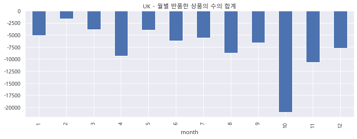

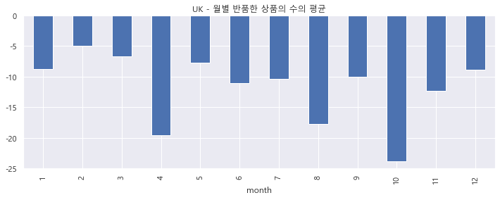

```python
plt.figure(figsize=(12,4))
uk_returned_month.Quantity.plot(kind = "bar");
plt.title('UK - 월별 반품한 상품의 수의 합계');

plt.figure(figsize=(12,4))
uk_returned_month2.Quantity.plot(kind = "bar");
plt.title('UK - 월별 반품한 상품의 수의 평균');
```

##### UK에서 반품이 가장 많이 된 day

```python
uk_returned_day = unitedkingdom_returned.groupby("day").sum()
uk_returned_day2 = unitedkingdom_returned.groupby("day").mean()
```

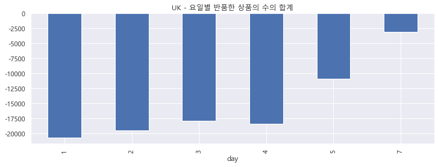

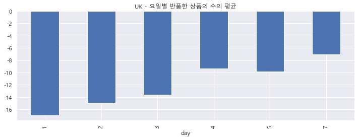

```python
plt.figure(figsize=(12,4))
uk_returned_day.Quantity.plot(kind = "bar");
plt.title('UK - 요일별 반품한 상품의 수의 합계');

plt.figure(figsize=(12,4))
uk_returned_day2.Quantity.plot(kind = "bar");
plt.title('UK - 요일별 반품한 상품의 수의 평균');
```

##### UK에서 반품이 가장 많이 된 hour

```python
uk_returned_hour = unitedkingdom_returned.groupby("hour").sum()
uk_returned_hour2 = unitedkingdom_returned.groupby("hour").mean()
```

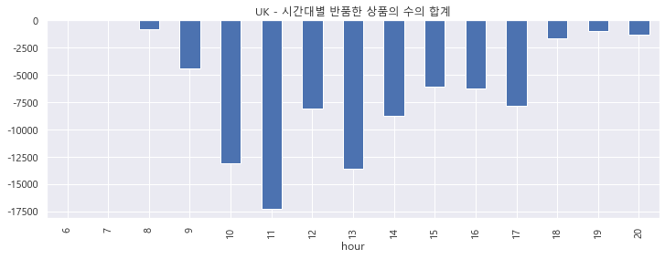

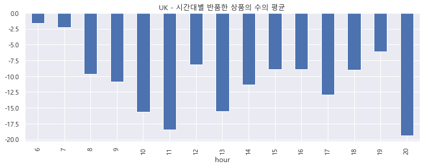

```python
plt.figure(figsize=(12,4))
uk_returned_hour.Quantity.plot(kind = "bar");
plt.title('UK - 시간대별 반품한 상품의 수의 합계');

plt.figure(figsize=(12,4))
uk_returned_hour2.Quantity.plot(kind = "bar");
plt.title('UK - 시간대별 반품한 상품의 수의 평균');
```

- UK의 반품 상품에 대한 시계열 분석 결과는 전체 국가에 대해 진행했던 시계열 분석의 결과와 유사합니다.

##### UK에서 가장 많이 반품된 상품

```python
unitedkingdom_returned.groupby("Description")
```

```
<pandas.core.groupby.generic.DataFrameGroupBy object at 0x00000215BF2B6460>
```

```python
uk_returned_Description = unitedkingdom_returned.groupby("Description").sum()
uk_returned_Description2 = unitedkingdom_returned.groupby("Description").mean()
```

```python
uk_returned_Description.sort_values(by = "Quantity").head(10)
```

| Description | Quantity | UnitPrice | TrAmount | year_month | month | day | hour |
| --- | --- | --- | --- | --- | --- | --- | --- |
| PINK BLUE FELT CRAFT TRINKET BOX | -2616 | 4.62 | -2777.52 | 804427 | 27 | 11 | 48 |
| WHITE HANGING HEART T-LIGHT HOLDER | -2551 | 112.00 | -6544.65 | 8043759 | 259 | 114 | 521 |
| GIN + TONIC DIET METAL SIGN | -2029 | 13.43 | -3772.78 | 1206541 | 41 | 14 | 78 |
| HERB MARKER BASIL | -1527 | 1.20 | -841.05 | 402213 | 13 | 5 | 22 |
| FELTCRAFT DOLL MOLLY | -1446 | 13.70 | -3509.70 | 1005455 | 55 | 15 | 62 |
| TEA TIME PARTY BUNTING | -1424 | 25.30 | -3692.95 | 1407734 | 34 | 20 | 82 |
| PAPER POCKET TRAVELING FAN | -1385 | 0.42 | -108.29 | 804435 | 35 | 13 | 58 |
| WORLD WAR 2 GLIDERS ASSTD DESIGNS | -1200 | 1.19 | -253.92 | 1005525 | 25 | 14 | 67 |
| COLOUR GLASS. STAR T-LIGHT HOLDER | -1171 | 69.38 | -3235.01 | 4424153 | 153 | 82 | 309 |
| JUMBO BAG RED RETROSPOT | -1101 | 77.77 | -1954.90 | 8245027 | 327 | 149 | 524 |

가장 반품량이 많은 상품은

1. PINK BLUE FELT CRAFT TRINKET BOX
2. WHITE HANGING HEART T-LIGHT HOLDER
3. GIN + TONIC DIET METAL SIGN

입니다.

이 역시도 전체 국가에 대해 시행했던 분석과 결과가 동일합니다.

#### United Kingdom - 금액

```python
uk_returned_Description.sort_values(by = "TrAmount").head(10)
```

| Description | Quantity | UnitPrice | TrAmount | year_month | month | day | hour |
| --- | --- | --- | --- | --- | --- | --- | --- |
| REGENCY CAKESTAND 3 TIER | -693 | 1775.40 | -7867.35 | 29762435 | 835 | 465 | 1948 |
| WHITE HANGING HEART T-LIGHT HOLDER | -2551 | 112.00 | -6544.65 | 8043759 | 259 | 114 | 521 |
| PANTRY CHOPPING BOARD | -946 | 30.01 | -4803.06 | 1206660 | 60 | 21 | 80 |
| DOORMAT FAIRY CAKE | -672 | 14.70 | -4538.40 | 402207 | 7 | 5 | 24 |
| GIN + TONIC DIET METAL SIGN | -2029 | 13.43 | -3772.78 | 1206541 | 41 | 14 | 78 |
| TEA TIME PARTY BUNTING | -1424 | 25.30 | -3692.95 | 1407734 | 34 | 20 | 82 |
| FELTCRAFT DOLL MOLLY | -1446 | 13.70 | -3509.70 | 1005455 | 55 | 15 | 62 |
| COLOUR GLASS. STAR T-LIGHT HOLDER | -1171 | 69.38 | -3235.01 | 4424153 | 153 | 82 | 309 |
| PINK BLUE FELT CRAFT TRINKET BOX | -2616 | 4.62 | -2777.52 | 804427 | 27 | 11 | 48 |
| IVORY DINER WALL CLOCK | -344 | 135.15 | -2653.70 | 3217608 | 108 | 58 | 240 |

상품이 아닌 항목을 제외한 상품 중 가장 반품 금액이 높은 상품은  
1위. REGENCY CAKESTAND 3 TIER  
2위. WHITE HANGING HEART T-LIGHT HOLDER  
3위. PANTRY CHOPPING BOARD  
입니다.

이 역시도 수량과 마찬가지로 전체 국가에 대해 시행했던 분석과 결과가 동일합니다.

### 나라별 분석2

```python
outlier_removed = returned2_df.query("Country != 'United Kingdom'")
outlier_removed
```

|  | StockCode | InvoiceNo | Description | Quantity | InvoiceDate | UnitPrice | CustomerID | Country | TrAmount | InvoiceDatetime | year_month | month | day | hour |
| --- | --- | --- | --- | --- | --- | --- | --- | --- | --- | --- | --- | --- | --- | --- |
| 677 | 90209C | C570828 | PINK ENAMEL+GLASS HAIR COMB | -3 | 2011-10-12 | 2.10 | 14911.0 | EIRE | -6.30 | 2011-10-12 13:15:00 | 201110 | 10 | 3 | 13 |
| 752 | 90209A | C570828 | PURPLE ENAMEL+GLASS HAIR COMB | -6 | 2011-10-12 | 2.10 | 14911.0 | EIRE | -12.60 | 2011-10-12 13:15:00 | 201110 | 10 | 3 | 13 |
| 756 | 90208 | C570828 | PAIR OF PINK FLOWER CLUSTER SLIDE | -6 | 2011-10-12 | 2.55 | 14911.0 | EIRE | -15.30 | 2011-10-12 13:15:00 | 201110 | 10 | 3 | 13 |
| 874 | 90204 | C570828 | PAIR OF ENAMEL BUTTERFLY HAIRCLIP | -4 | 2011-10-12 | 3.35 | 14911.0 | EIRE | -13.40 | 2011-10-12 13:15:00 | 201110 | 10 | 3 | 13 |
| 885 | 90202D | C570828 | PINK ENAMEL FLOWER HAIR TIE | -6 | 2011-10-12 | 2.95 | 14911.0 | EIRE | -17.70 | 2011-10-12 13:15:00 | 201110 | 10 | 3 | 13 |
| ... | ... | ... | ... | ... | ... | ... | ... | ... | ... | ... | ... | ... | ... | ... |
| 533735 | 15056P | C539576 | EDWARDIAN PARASOL PINK | -6 | 2010-12-20 | 5.95 | 14911.0 | EIRE | -35.70 | 2010-12-20 12:25:00 | 201012 | 12 | 1 | 12 |
| 533817 | 15056N | C557663 | EDWARDIAN PARASOL NATURAL | -12 | 2011-06-21 | 5.95 | %EMPTY% | EIRE | -71.40 | 2011-06-21 17:59:00 | 201106 | 6 | 2 | 17 |
| 534044 | 15056N | C569490 | EDWARDIAN PARASOL NATURAL | -33 | 2011-10-04 | 5.95 | 12457.0 | Cyprus | -196.35 | 2011-10-04 13:15:00 | 201110 | 10 | 2 | 13 |
| 534130 | 15056N | C539576 | EDWARDIAN PARASOL NATURAL | -6 | 2010-12-20 | 5.95 | 14911.0 | EIRE | -35.70 | 2010-12-20 12:25:00 | 201012 | 12 | 1 | 12 |
| 534428 | 15056BL | C539576 | EDWARDIAN PARASOL BLACK | -6 | 2010-12-20 | 5.95 | 14911.0 | EIRE | -35.70 | 2010-12-20 12:25:00 | 201012 | 12 | 1 | 12 |

1341 rows × 14 columns

```python
outlier_removed_month = outlier_removed.groupby("month").sum()
outlier_removed_month2 = outlier_removed.groupby("month").mean()
```

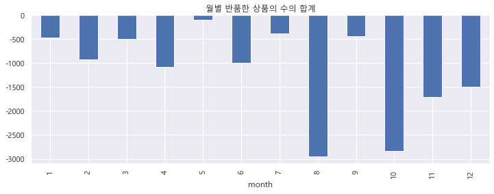

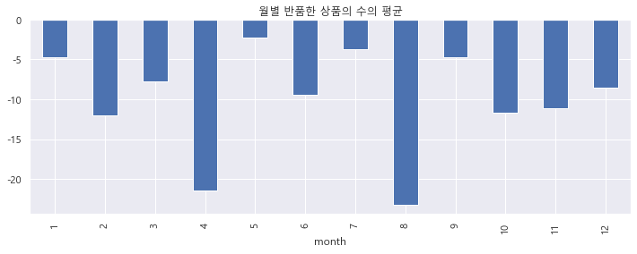

```python
plt.figure(figsize=(12,4))
outlier_removed_month.Quantity.plot(kind = "bar");
plt.title('월별 반품한 상품의 수의 합계');

plt.figure(figsize=(12,4))
outlier_removed_month2.Quantity.plot(kind = "bar");
plt.title('월별 반품한 상품의 수의 평균');
```

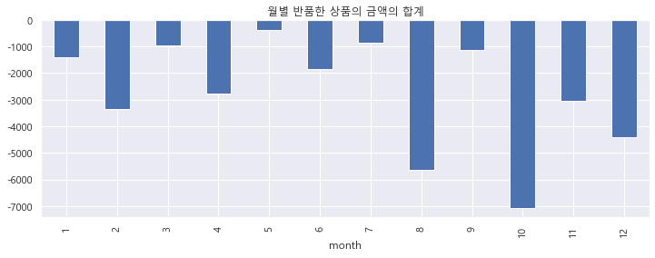

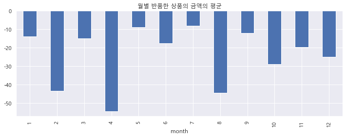

```python
plt.figure(figsize=(12,4))
outlier_removed_month.TrAmount.plot(kind = "bar");
plt.title('월별 반품한 상품의 금액의 합계');

plt.figure(figsize=(12,4))
outlier_removed_month2.TrAmount.plot(kind = "bar");
plt.title('월별 반품한 상품의 금액의 평균');
```

```python
outlier_removed_day = outlier_removed.groupby("day").sum()
outlier_removed_day2 = outlier_removed.groupby("day").mean()
```

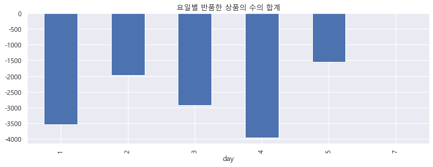

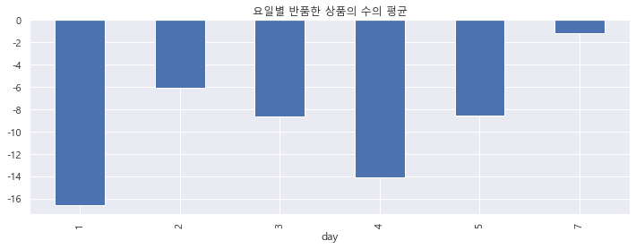

```python
plt.figure(figsize=(12,4))
outlier_removed_day.Quantity.plot(kind = "bar");
plt.title('요일별 반품한 상품의 수의 합계');

plt.figure(figsize=(12,4))
outlier_removed_day2.Quantity.plot(kind = "bar");
plt.title('요일별 반품한 상품의 수의 평균');
```

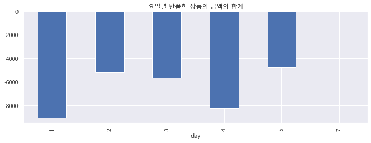

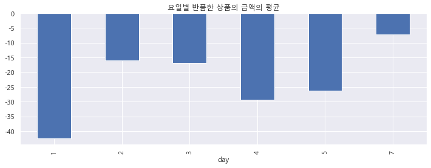

```python
plt.figure(figsize=(12,4))
outlier_removed_day.TrAmount.plot(kind = "bar");
plt.title('요일별 반품한 상품의 금액의 합계');

plt.figure(figsize=(12,4))
outlier_removed_day2.TrAmount.plot(kind = "bar");
plt.title('요일별 반품한 상품의 금액의 평균');
```

- 요일별 분석의 결과는 앞선 분석과 동일하게 월요일, 목요일에 반품 수량과 금액이 큰 것이 확인되었고, 주말에는 현저히 적은 것을 알 수 있습니다.

```python
outlier_removed_hour = outlier_removed.groupby("hour").sum()
outlier_removed_hour2 = outlier_removed.groupby("hour").mean()
```

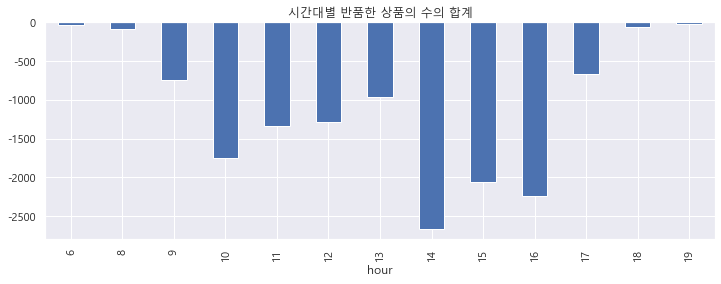

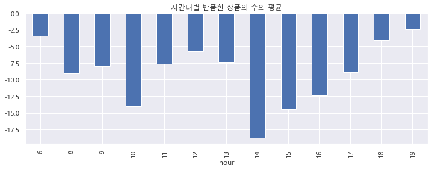

```python
plt.figure(figsize=(12,4))
outlier_removed_hour.Quantity.plot(kind = "bar");
plt.title('시간대별 반품한 상품의 수의 합계');

plt.figure(figsize=(12,4))
outlier_removed_hour2.Quantity.plot(kind = "bar");
plt.title('시간대별 반품한 상품의 수의 평균');
```

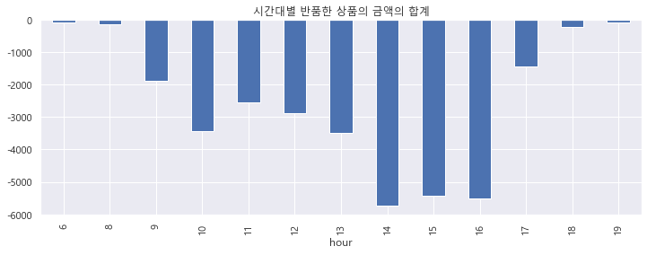

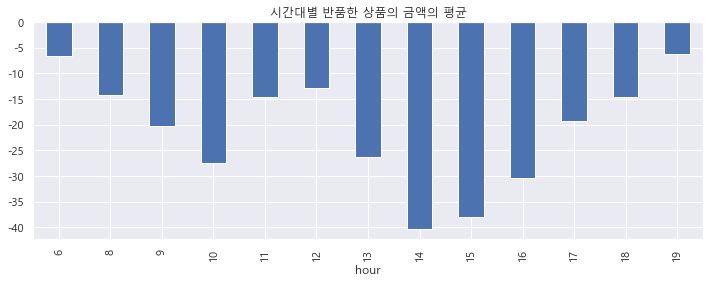

```python
plt.figure(figsize=(12,4))
outlier_removed_hour.TrAmount.plot(kind = "bar");
plt.title('시간대별 반품한 상품의 금액의 합계');

plt.figure(figsize=(12,4))
outlier_removed_hour2.TrAmount.plot(kind = "bar");
plt.title('시간대별 반품한 상품의 금액의 평균');
```

- 앞선 분석 결과에서는 9시부터 점차 증가하다 11시에 최대치를 찍고 점차 감소하는 양상을 보였습니다. 또, 12시에 최저점을 기록했습니다.
- 그러나 이번 분석 결과를 보면 수량은 오히려 13시에 최저점을 기록했고 수량과 금액 모두 14시에 최대치를 기록한 것을 알 수 있습니다.
- 13시에 반품 수량은 적으나 반품 금액은 상대적으로 큰 것을 보면 비교적 단가가 비싼 상품들이 반품되었다는 것을 알 수 있습니다.

```python
outlier_removed_Description = outlier_removed.groupby("Description").sum()
outlier_removed_Description2 = outlier_removed.groupby("Description").mean()
outlier_removed_Description.sort_values(by = "Quantity").head(10)
```

| Description | Quantity | UnitPrice | TrAmount | year_month | month | day | hour |
| --- | --- | --- | --- | --- | --- | --- | --- |
| ROUND SNACK BOXES SET OF 4 FRUITS | -645 | 29.10 | -1653.15 | 2011054 | 54 | 22 | 125 |
| 36 DOILIES VINTAGE CHRISTMAS | -288 | 1.25 | -360.00 | 201108 | 8 | 4 | 14 |
| BOYS ALPHABET IRON ON PATCHES | -288 | 0.21 | -60.48 | 201111 | 11 | 1 | 10 |
| VANILLA SCENT CANDLE JEWELLED BOX | -288 | 1.25 | -360.00 | 201110 | 10 | 1 | 15 |
| WRAP CHRISTMAS VILLAGE | -275 | 0.84 | -115.50 | 402221 | 21 | 4 | 31 |
| OCEAN SCENT CANDLE IN JEWELLED BOX | -254 | 5.06 | -455.74 | 402211 | 11 | 4 | 26 |
| SET OF 3 BABUSHKA STACKING TINS | -246 | 13.45 | -1213.50 | 603215 | 15 | 8 | 39 |
| SET OF 6 NATIVITY MAGNETS | -240 | 1.85 | -444.00 | 201108 | 8 | 4 | 14 |
| 60 CAKE CASES VINTAGE CHRISTMAS | -240 | 0.42 | -100.80 | 201108 | 8 | 4 | 14 |
| DOLLY GIRL LUNCH BOX | -204 | 7.50 | -340.20 | 804328 | 28 | 16 | 53 |

```python
outlier_removed_Description2.sort_values(by = "Quantity").head(10)
```

| Description | Quantity | UnitPrice | TrAmount | year_month | month | day | hour |
| --- | --- | --- | --- | --- | --- | --- | --- |
| BOYS ALPHABET IRON ON PATCHES | -288.0 | 0.21 | -60.48 | 201111.0 | 11.0 | 1.0 | 10.0 |
| VANILLA SCENT CANDLE JEWELLED BOX | -288.0 | 1.25 | -360.00 | 201110.0 | 10.0 | 1.0 | 15.0 |
| 36 DOILIES VINTAGE CHRISTMAS | -288.0 | 1.25 | -360.00 | 201108.0 | 8.0 | 4.0 | 14.0 |
| 60 CAKE CASES VINTAGE CHRISTMAS | -240.0 | 0.42 | -100.80 | 201108.0 | 8.0 | 4.0 | 14.0 |
| SET OF 6 NATIVITY MAGNETS | -240.0 | 1.85 | -444.00 | 201108.0 | 8.0 | 4.0 | 14.0 |
| PAPER CHAIN KIT VINTAGE CHRISTMAS | -200.0 | 2.55 | -510.00 | 201108.0 | 8.0 | 4.0 | 14.0 |
| SET OF 20 VINTAGE CHRISTMAS NAPKINS | -192.0 | 0.72 | -138.24 | 201108.0 | 8.0 | 4.0 | 14.0 |
| CHRISTMAS METAL TAGS ASSORTED | -144.0 | 0.72 | -103.68 | 201108.0 | 8.0 | 4.0 | 14.0 |
| VICTORIAN SEWING KIT | -144.0 | 1.25 | -180.00 | 201103.0 | 3.0 | 4.0 | 9.0 |
| RAIN PONCHO RETROSPOT | -144.0 | 0.65 | -93.60 | 201108.0 | 8.0 | 3.0 | 11.0 |

상품들 중 반품 수량이 가장 많은 상품은

1. ROUND SNACK BOXES SET OF 4 FRUITS
2. 36 DOILIES VINTAGE CHRISTMAS
3. BOYS ALPHABET IRON ON PATCHES

입니다.

```python
outlier_removed_Description.sort_values(by = "TrAmount").head(10)
```

| Description | Quantity | UnitPrice | TrAmount | year_month | month | day | hour |
| --- | --- | --- | --- | --- | --- | --- | --- |
| REGENCY CAKESTAND 3 TIER | -164 | 393.75 | -1855.20 | 6636397 | 197 | 104 | 426 |
| ROUND SNACK BOXES SET OF 4 FRUITS | -645 | 29.10 | -1653.15 | 2011054 | 54 | 22 | 125 |
| 3 TIER CAKE TIN RED AND CREAM | -96 | 12.75 | -1224.00 | 201102 | 2 | 5 | 16 |
| SET OF 3 BABUSHKA STACKING TINS | -246 | 13.45 | -1213.50 | 603215 | 15 | 8 | 39 |
| CINDERELLA CHANDELIER | -12 | 91.70 | -517.40 | 402220 | 20 | 4 | 28 |
| PAPER CHAIN KIT VINTAGE CHRISTMAS | -200 | 2.55 | -510.00 | 201108 | 8 | 4 | 14 |
| ROSES REGENCY TEACUP AND SAUCER | -191 | 22.80 | -496.25 | 1608860 | 60 | 31 | 109 |
| OCEAN SCENT CANDLE IN JEWELLED BOX | -254 | 5.06 | -455.74 | 402211 | 11 | 4 | 26 |
| SET OF 6 NATIVITY MAGNETS | -240 | 1.85 | -444.00 | 201108 | 8 | 4 | 14 |
| COTTON APRON PANTRY DESIGN | -102 | 9.20 | -434.90 | 402215 | 15 | 6 | 22 |

상품들 중 반품 금액이 가장 큰 상품은

1. REGENCY CAKESTAND 3 TIER
2. ROUND SNACK BOXES SET OF 4 FRUITS
3. 3 TIER CAKE TIN RED AND CREAM

입니다.

[반품량 감소 방안]

위의 두 데이터 프레임을 보면 다수의 항목이 크리스마스와 연관이 있는 것을 알 수 있습니다.

그러나 outlier_removed_Description2 를 보면 반품하는 시기가 8월인 것을 확인할 수 있습니다.

미리 크리스마스 준비를 하기 위해 주문했다 마음에 들지 않아 취소한다면 8월에 미리 크리스마스 시즌에 세일 행사를 진행할 것이라는 공지를 띄우면 반품량이 줄어들 것이라 생각합니다.

8월부터 마음에 드는 상품들을 고르고 크리스마스 시즌을 기다리면 상품에 대해 고민하는 시간도 증가하게 됩니다. 실제로 기간을 여유 있게 줄수록 반퓸률이 감소한다는 연구도 있습니다. 따라서 구매할 제품에 대한 충분한 판단 후에 구매를 하게 되면 반품량이 감소할 것이라 예상됩니다.

## Q2. 할인과 반품에 어떠한 관계가 있는지 자유롭게 살펴보세요.

데이터를 살펴보며 가설 수립, 검증, 결론 등으로 자유로운 보고를 수행해보세요.

가설 : 할인이 많이 된 제품일수록 반품할 확률이 낮다.  
-> 할인율과 반품율의 상관관계 알아보기

- Quantity < 0 이면 반품으로 간주
- UnitPrice의 표준편차가 0이 아니면 할인이 적어도 한번 되었던 것으로 간주

```
<function matplotlib.pyplot.show(close=None, block=None)>
```

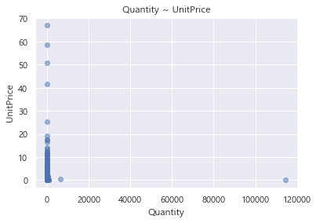

```python
X = ecmm_df.groupby("StockCode").std().Quantity.values
Y = ecmm_df.groupby("StockCode").std().UnitPrice.values

plt.scatter(X,Y,alpha = 0.5)
plt.title("Quantity ~ UnitPrice")
plt.xlabel("Quantity")
plt.ylabel("UnitPrice")
plt.show
```

이상치 때문에 제대로 된 산점도가 안 나오기 때문에 이상치를 제거한 후 다시 해보도록 하겠습니다.  
(이상치 = 평균 +- 2 x 표준편차) 로 간주하도록 하겠습니다.

```python
ecmm_df.describe()
```

|  | Quantity | UnitPrice | TrAmount | year_month | month | day | hour |
| --- | --- | --- | --- | --- | --- | --- | --- |
| count | 536465.000000 | 536465.000000 | 536465.000000 | 536465.000000 | 536465.000000 | 536465.000000 | 536465.000000 |
| mean | 9.888945 | 3.284049 | 18.254143 | 201099.727211 | 7.558663 | 3.434530 | 13.078219 |
| std | 215.960447 | 4.497161 | 367.948652 | 25.779125 | 3.508951 | 1.847357 | 2.443185 |
| min | -80995.000000 | 0.001000 | -168469.600000 | 201012.000000 | 1.000000 | 1.000000 | 6.000000 |
| 25% | 1.000000 | 1.250000 | 3.750000 | 201103.000000 | 5.000000 | 2.000000 | 11.000000 |
| 50% | 3.000000 | 2.080000 | 9.780000 | 201107.000000 | 8.000000 | 3.000000 | 13.000000 |
| 75% | 10.000000 | 4.130000 | 17.400000 | 201110.000000 | 11.000000 | 5.000000 | 15.000000 |
| max | 80995.000000 | 649.500000 | 168469.600000 | 201112.000000 | 12.000000 | 7.000000 | 20.000000 |

```python
9.888945 + 2*215.960447
```

```
441.80983899999995
```

```python
9.888945 - 2*215.960447
```

```
-422.031949
```

```python
3.284049 + 2*4.497161
```

```
12.278371
```

```python
3.284049 - 2*4.497161
```

```
-5.710273000000001
```

```python
df4 = ecmm_df.query("Quantity < 441.80983899999995")
```

```python
df4 = df4.query("UnitPrice < 12.278371")
```

```python
df4 = df4.query("Quantity > -422.031949")
```

```
<function matplotlib.pyplot.show(close=None, block=None)>
```

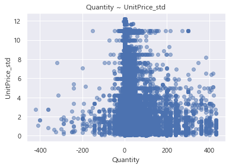

```python
X = df4.Quantity.values
Y = df4.UnitPrice.values

plt.scatter(X,Y,alpha = 0.5)
plt.title("Quantity ~ UnitPrice_std")
plt.xlabel("Quantity")
plt.ylabel("UnitPrice_std")
plt.show
```

산점도를 통해서는 눈에 띄는 선형성이나 상관관계를 파악하기에는 힘든 것 같아서 수치를 통해 분석해 보도록 하겠습니다.

```python
# 공분산
np.cov(X,Y)[0,1]
```

```
-9.509237953938216
```

공분산은 절대적 선형성을 파악하기에는 한계가 있어 상관계수를 알아보도록 하겠습니다.

```python
# 상관계수
np.corrcoef(X,Y)[0,1]
```

```
-0.1819461033852523
```

보통 상관계수 값이 0에 가까울수록 선형관계가 성립되지 않고, 상관계수의 절댓값이 0.3 ~ 0.7 일 때 약한 상관관계가 있다고 간주합니다.  
이 경우에는 절댓값이 0.18로 이에 못 미치는 것을 알 수 있습니다.

제대로 p-value를 통해 상관분석을 진행해 보도록 하겠습니다.

```python
import scipy.stats as stats
stats.pearsonr(X,Y)
```

```
(-0.1819461033852503, 0.0)
```

실제로 데이터를 조금 더 긴밀하게 살펴보도록 하겠습니다.

```python
q2_df1 = ecmm_df.groupby("StockCode").std().iloc[:,1:2].query("UnitPrice>0")
q2_df1
```

| StockCode | UnitPrice |
| --- | --- |
| 10002 | 0.367792 |
| 10080 | 0.098072 |
| 10125 | 0.272576 |
| 10133 | 0.248819 |
| 10135 | 0.637701 |
| ... | ... |
| 90214Y | 0.319005 |
| 90214Z | 0.173128 |
| DCGS0003 | 0.028868 |
| DCGSSBOY | 0.615083 |
| DCGSSGIRL | 0.565794 |

3364 rows × 1 columns

```python
q2_df2 = ecmm_df.set_index("StockCode").iloc[:,2:3].query("Quantity < 0")
q2_df2
```

| StockCode | Quantity |
| --- | --- |
| 90211B | -2 |
| 90209C | -3 |
| 90209A | -6 |
| 90208 | -6 |
| 90204 | -4 |
| ... | ... |
| 11001 | -1 |
| 11001 | -180 |
| 11001 | -1 |
| 10135 | -1 |
| 10133 | -10 |

8704 rows × 1 columns

```python
q2_df3 = pd.concat([q2_df1,q2_df2])
```

```python
q2_df3 = q2_df3.query("UnitPrice > 0")
```

```python
q2_df3 = q2_df3.query("Quantity < 0")
```

```python
print(q2_df3.describe())
q2_df3
```

```
       UnitPrice  Quantity
count        0.0       0.0
mean         NaN       NaN
std          NaN       NaN
min          NaN       NaN
25%          NaN       NaN
50%          NaN       NaN
75%          NaN       NaN
max          NaN       NaN
```

|  | UnitPrice | Quantity |
| --- | --- | --- |
| StockCode |  |  |

## Q3. 적절한 마케팅 대상을 선별하기 위해 고객 Segment를 나누고자 합니다.

사업적으로 가장 효과가 뛰어날 것 같은 마케팅 전략을 수립하고, 대상 고객 Segment를 선별하여 마케팅 전략을 수립해보세요.  
또는 반대 방향으로 Segment를 먼저 분석한 후, 마케팅 전략을 제안하여도 좋습니다.

```python
ecmm_df.groupby("CustomerID").sum().query("CustomerID != '%EMPTY%'").sort_values(by = "TrAmount", ascending = False).head(10)
```

| CustomerID | Quantity | UnitPrice | TrAmount | year_month | month | day | hour |
| --- | --- | --- | --- | --- | --- | --- | --- |
| 14646.0 | 196556 | 4935.59 | 278778.02 | 414675349 | 14049 | 6483 | 24262 |
| 18102.0 | 64124 | 1940.92 | 259657.30 | 86676046 | 3746 | 1261 | 5587 |
| 17450.0 | 69041 | 1156.73 | 189735.53 | 68376021 | 2321 | 851 | 4170 |
| 14911.0 | 76848 | 19652.47 | 128882.13 | 1168608390 | 47490 | 19357 | 69897 |
| 12415.0 | 76946 | 1887.09 | 123638.18 | 155656054 | 4654 | 2284 | 8753 |
| 14156.0 | 57013 | 4773.11 | 113855.32 | 282754777 | 8677 | 4313 | 17325 |
| 17511.0 | 63014 | 2594.26 | 88138.20 | 215979214 | 8014 | 3005 | 12784 |
| 16684.0 | 49391 | 681.89 | 65920.12 | 56307800 | 2100 | 1062 | 3248 |
| 13694.0 | 61808 | 908.81 | 62924.10 | 117039279 | 3779 | 1953 | 7168 |
| 15311.0 | 37720 | 6267.75 | 59419.34 | 500937057 | 16357 | 7965 | 32042 |

소비한 금액이 가장 큰 10명을 추출해 보았습니다.

```python
ecmm_df.set_index("CustomerID").loc[14646.0,:].sort_values(by = "TrAmount",ascending = False)
```

| CustomerID | StockCode | InvoiceNo | Description | Quantity | InvoiceDate | UnitPrice | Country | TrAmount | InvoiceDatetime | year_month | month | day | hour |
| --- | --- | --- | --- | --- | --- | --- | --- | --- | --- | --- | --- | --- | --- |
| 14646.0 | 23084 | 573003 | RABBIT NIGHT LIGHT | 2400 | 2011-10-27 | 2.08 | Netherlands | 4992.00 | 2011-10-27 12:11:00 | 201110 | 10 | 4 | 12 |
| 14646.0 | 23084 | 581175 | RABBIT NIGHT LIGHT | 1440 | 2011-12-07 | 1.79 | Netherlands | 2577.60 | 2011-12-07 15:16:00 | 201112 | 12 | 3 | 15 |
| 14646.0 | 22243 | 554642 | 5 HOOK HANGER RED MAGIC TOADSTOOL | 960 | 2011-05-25 | 1.45 | Netherlands | 1392.00 | 2011-05-25 12:19:00 | 201105 | 5 | 3 | 12 |
| 14646.0 | 22595 | 572052 | GINGHAM HEART DECORATION | 1728 | 2011-10-20 | 0.72 | Netherlands | 1244.16 | 2011-10-20 12:26:00 | 201110 | 10 | 4 | 12 |
| 14646.0 | 22630 | 548011 | DOLLY GIRL LUNCH BOX | 640 | 2011-03-29 | 1.65 | Netherlands | 1056.00 | 2011-03-29 11:14:00 | 201103 | 3 | 2 | 11 |
| ... | ... | ... | ... | ... | ... | ... | ... | ... | ... | ... | ... | ... | ... |
| 14646.0 | 22614 | 574059 | PACK OF 12 SPACEBOY TISSUES | 1 | 2011-11-02 | 0.39 | Netherlands | 0.39 | 2011-11-02 14:13:00 | 201111 | 11 | 3 | 14 |
| 14646.0 | 23380 | 574059 | PACK OF 12 VINTAGE DOILY TISSUES | 1 | 2011-11-02 | 0.39 | Netherlands | 0.39 | 2011-11-02 14:13:00 | 201111 | 11 | 3 | 14 |
| 14646.0 | 23551 | 574059 | PACK OF 12 PAISLEY PARK TISSUES | 1 | 2011-11-02 | 0.39 | Netherlands | 0.39 | 2011-11-02 14:13:00 | 201111 | 11 | 3 | 14 |
| 14646.0 | 21787 | C564899 | RAIN PONCHO RETROSPOT | -144 | 2011-08-31 | 0.65 | Netherlands | -93.60 | 2011-08-31 11:31:00 | 201108 | 8 | 3 | 11 |
| 14646.0 | 22956 | C564899 | 36 FOIL HEART CAKE CASES | -144 | 2011-08-31 | 1.85 | Netherlands | -266.40 | 2011-08-31 11:31:00 | 201108 | 8 | 3 | 11 |

2062 rows × 13 columns

```python
ecmm_df.set_index("CustomerID").loc[14646.0,:].groupby("Description").sum().sort_values(by = "TrAmount",ascending = False).head(10)
```

| Description | Quantity | UnitPrice | TrAmount | year_month | month | day | hour |
| --- | --- | --- | --- | --- | --- | --- | --- |
| RABBIT NIGHT LIGHT | 4801 | 14.27 | 9568.48 | 1407757 | 57 | 24 | 89 |
| ROUND SNACK BOXES SET OF4 WOODLAND | 3120 | 61.20 | 7956.00 | 4826449 | 149 | 80 | 273 |
| SPACEBOY LUNCH BOX | 4492 | 41.55 | 7415.40 | 5027555 | 155 | 77 | 296 |
| DOLLY GIRL LUNCH BOX | 4096 | 31.35 | 6758.40 | 3821015 | 115 | 58 | 217 |
| ROUND SNACK BOXES SET OF 4 FRUITS | 1584 | 43.35 | 4039.20 | 3418799 | 99 | 52 | 189 |
| JUMBO BAG RED RETROSPOT | 2000 | 24.22 | 3468.00 | 2815477 | 77 | 39 | 159 |
| RED TOADSTOOL LED NIGHT LIGHT | 2376 | 19.25 | 3459.60 | 2614292 | 92 | 42 | 161 |
| REGENCY CAKESTAND 3 TIER | 288 | 87.60 | 3153.60 | 1608854 | 54 | 23 | 100 |
| 5 HOOK HANGER RED MAGIC TOADSTOOL | 2016 | 10.15 | 2923.20 | 1407721 | 21 | 22 | 77 |
| JUMBO BAG WOODLAND ANIMALS | 1500 | 19.27 | 2629.00 | 2212174 | 74 | 33 | 129 |

```python
ecmm_df.set_index("CustomerID").loc[18102.0,:].sort_values(by = "TrAmount",ascending = False)
```

| CustomerID | StockCode | InvoiceNo | Description | Quantity | InvoiceDate | UnitPrice | Country | TrAmount | InvoiceDatetime | year_month | month | day | hour |
| --- | --- | --- | --- | --- | --- | --- | --- | --- | --- | --- | --- | --- | --- |
| 18102.0 | 21623 | 537659 | VINTAGE UNION JACK MEMOBOARD | 600 | 2010-12-07 | 6.38 | United Kingdom | 3828.00 | 2010-12-07 16:43:00 | 201012 | 12 | 2 | 16 |
| 18102.0 | 23553 | 572209 | LANDMARK FRAME CAMDEN TOWN | 300 | 2011-10-21 | 10.95 | United Kingdom | 3285.00 | 2011-10-21 12:08:00 | 201110 | 10 | 5 | 12 |
| 18102.0 | 23558 | 572209 | LANDMARK FRAME LONDON BRIDGE | 300 | 2011-10-21 | 10.95 | United Kingdom | 3285.00 | 2011-10-21 12:08:00 | 201110 | 10 | 5 | 12 |
| 18102.0 | 23557 | 572209 | LANDMARK FRAME BAKER STREET | 300 | 2011-10-21 | 10.95 | United Kingdom | 3285.00 | 2011-10-21 12:08:00 | 201110 | 10 | 5 | 12 |
| 18102.0 | 23556 | 572209 | LANDMARK FRAME COVENT GARDEN | 300 | 2011-10-21 | 10.95 | United Kingdom | 3285.00 | 2011-10-21 12:08:00 | 201110 | 10 | 5 | 12 |
| ... | ... | ... | ... | ... | ... | ... | ... | ... | ... | ... | ... | ... | ... |
| 18102.0 | 22189 | 574355 | CREAM HEART CARD HOLDER | 4 | 2011-11-04 | 2.31 | United Kingdom | 9.24 | 2011-11-04 10:48:00 | 201111 | 11 | 5 | 10 |
| 18102.0 | 23404 | 569257 | HOME SWEET HOME BLACKBOARD | 2 | 2011-10-03 | 3.26 | United Kingdom | 6.52 | 2011-10-03 11:24:00 | 201110 | 10 | 1 | 11 |
| 18102.0 | 82484 | 574383 | WOOD BLACK BOARD ANT WHITE FINISH | 1 | 2011-11-04 | 4.80 | United Kingdom | 4.80 | 2011-11-04 11:03:00 | 201111 | 11 | 5 | 11 |
| 18102.0 | 22188 | 574383 | BLACK HEART CARD HOLDER | 2 | 2011-11-04 | 2.31 | United Kingdom | 4.62 | 2011-11-04 11:03:00 | 201111 | 11 | 5 | 11 |
| 18102.0 | 23404 | 574383 | HOME SWEET HOME BLACKBOARD | 1 | 2011-11-04 | 3.26 | United Kingdom | 3.26 | 2011-11-04 11:03:00 | 201111 | 11 | 5 | 11 |

431 rows × 13 columns

```python
ecmm_df.set_index("CustomerID").loc[18102.0,:].groupby("Description").sum().sort_values(by = "TrAmount",ascending = False).head(10)
```

| Description | Quantity | UnitPrice | TrAmount | year_month | month | day | hour |
| --- | --- | --- | --- | --- | --- | --- | --- |
| VINTAGE UNION JACK MEMOBOARD | 2600 | 44.68 | 16592.08 | 1407542 | 42 | 15 | 98 |
| WOOD BLACK BOARD ANT WHITE FINISH | 3205 | 91.11 | 15351.00 | 3820756 | 156 | 64 | 253 |
| CREAM HEART CARD HOLDER | 5946 | 51.93 | 14089.90 | 4424078 | 178 | 67 | 289 |
| BLACK HEART CARD HOLDER | 4104 | 36.97 | 9482.40 | 3217447 | 147 | 55 | 213 |
| DOORMAT NEW ENGLAND | 1620 | 32.06 | 7419.60 | 1407749 | 49 | 17 | 97 |
| DOORMAT HEARTS | 1620 | 32.06 | 7419.60 | 1407749 | 49 | 17 | 97 |
| DOORMAT FANCY FONT HOME SWEET HOME | 1300 | 27.48 | 5954.00 | 1206640 | 40 | 13 | 82 |
| DOORMAT WELCOME PUPPIES | 1270 | 32.06 | 5816.60 | 1407749 | 49 | 17 | 97 |
| LARGE ZINC HEART WALL ORGANISER | 976 | 35.28 | 5738.88 | 1206638 | 38 | 16 | 71 |
| DOORMAT BLACK FLOCK | 1213 | 32.06 | 5555.54 | 1407749 | 49 | 17 | 97 |

```python
ecmm_df.set_index("CustomerID").loc[17450.0,:].sort_values(by = "TrAmount",ascending = False)
```

| CustomerID | StockCode | InvoiceNo | Description | Quantity | InvoiceDate | UnitPrice | Country | TrAmount | InvoiceDatetime | year_month | month | day | hour |
| --- | --- | --- | --- | --- | --- | --- | --- | --- | --- | --- | --- | --- | --- |
| 17450.0 | 23243 | 567423 | SET OF TEA COFFEE SUGAR TINS PANTRY | 1412 | 2011-09-20 | 5.06 | United Kingdom | 7144.72 | 2011-09-20 11:05:00 | 201109 | 9 | 2 | 11 |
| 17450.0 | 22470 | 540689 | HEART OF WICKER LARGE | 1284 | 2011-01-11 | 3.21 | United Kingdom | 4121.64 | 2011-01-11 08:43:00 | 201101 | 1 | 2 | 8 |
| 17450.0 | 23113 | 567423 | PANTRY CHOPPING BOARD | 756 | 2011-09-20 | 5.06 | United Kingdom | 3825.36 | 2011-09-20 11:05:00 | 201109 | 9 | 2 | 11 |
| 17450.0 | 22722 | 567423 | SET OF 6 SPICE TINS PANTRY DESIGN | 852 | 2011-09-20 | 4.25 | United Kingdom | 3621.00 | 2011-09-20 11:05:00 | 201109 | 9 | 2 | 11 |
| 17450.0 | 85123A | 540689 | WHITE HANGING HEART T-LIGHT HOLDER | 1010 | 2011-01-11 | 3.24 | United Kingdom | 3272.40 | 2011-01-11 08:43:00 | 201101 | 1 | 2 | 8 |
| ... | ... | ... | ... | ... | ... | ... | ... | ... | ... | ... | ... | ... | ... |
| 17450.0 | 82578 | 540691 | KITCHEN METAL SIGN | 12 | 2011-01-11 | 0.73 | United Kingdom | 8.76 | 2011-01-11 08:50:00 | 201101 | 1 | 2 | 8 |
| 17450.0 | 23243 | 573452 | SET OF TEA COFFEE SUGAR TINS PANTRY | 4 | 2011-10-31 | 1.71 | United Kingdom | 6.84 | 2011-10-31 10:45:00 | 201110 | 10 | 1 | 10 |
| 17450.0 | 22470 | C579277 | HEART OF WICKER LARGE | -10 | 2011-11-29 | 3.20 | United Kingdom | -32.00 | 2011-11-29 10:16:00 | 201111 | 11 | 2 | 10 |
| 17450.0 | 23113 | C568832 | PANTRY CHOPPING BOARD | -186 | 2011-09-29 | 5.15 | United Kingdom | -957.90 | 2011-09-29 11:35:00 | 201109 | 9 | 4 | 11 |
| 17450.0 | 23113 | C567527 | PANTRY CHOPPING BOARD | -756 | 2011-09-21 | 5.06 | United Kingdom | -3825.36 | 2011-09-21 09:16:00 | 201109 | 9 | 3 | 9 |

340 rows × 13 columns

```python
ecmm_df.set_index("CustomerID").loc[17450.0,:].groupby("Description").sum().sort_values(by = "TrAmount",ascending = False).head(10)
```

| Description | Quantity | UnitPrice | TrAmount | year_month | month | day | hour |
| --- | --- | --- | --- | --- | --- | --- | --- |
| HEART OF WICKER LARGE | 4272 | 34.60 | 13427.64 | 2212088 | 88 | 27 | 131 |
| WHITE HANGING HEART T-LIGHT HOLDER | 4114 | 28.96 | 13253.84 | 1809971 | 71 | 25 | 110 |
| SET OF TEA COFFEE SUGAR TINS PANTRY | 2109 | 26.37 | 10566.73 | 1206655 | 55 | 13 | 76 |
| HEART OF WICKER SMALL | 5286 | 19.30 | 10201.98 | 2010975 | 75 | 26 | 122 |
| RED HANGING HEART T-LIGHT HOLDER | 2428 | 25.76 | 7832.16 | 1608860 | 60 | 24 | 102 |
| SET OF 6 SPICE TINS PANTRY DESIGN | 1326 | 11.95 | 5424.30 | 603323 | 23 | 9 | 49 |
| SET OF 3 CAKE TINS PANTRY DESIGN | 1000 | 19.59 | 4985.16 | 804434 | 34 | 11 | 58 |
| PANTRY ROLLING PIN | 1104 | 11.59 | 4415.28 | 603323 | 23 | 9 | 49 |
| COOK WITH WINE METAL SIGN | 1644 | 26.04 | 3933.72 | 2212193 | 93 | 27 | 138 |
| HOMEMADE JAM SCENTED CANDLES | 2124 | 3.40 | 3610.80 | 402217 | 17 | 5 | 31 |

```python
ecmm_df.groupby("CustomerID").sum().query("CustomerID != '%EMPTY%'").sort_values(by = "Quantity", ascending = False).head(10)
```

| CustomerID | Quantity | UnitPrice | TrAmount | year_month | month | day | hour |
| --- | --- | --- | --- | --- | --- | --- | --- |
| 14646.0 | 196556 | 4935.59 | 278778.02 | 414675349 | 14049 | 6483 | 24262 |
| 12415.0 | 76946 | 1887.09 | 123638.18 | 155656054 | 4654 | 2284 | 8753 |
| 14911.0 | 76848 | 19652.47 | 128882.13 | 1168608390 | 47490 | 19357 | 69897 |
| 17450.0 | 69041 | 1156.73 | 189735.53 | 68376021 | 2321 | 851 | 4170 |
| 18102.0 | 64124 | 1940.92 | 259657.30 | 86676046 | 3746 | 1261 | 5587 |
| 17511.0 | 63014 | 2594.26 | 88138.20 | 215979214 | 8014 | 3005 | 12784 |
| 13694.0 | 61808 | 908.81 | 62924.10 | 117039279 | 3779 | 1953 | 7168 |
| 14298.0 | 58021 | 2455.50 | 50862.44 | 329800501 | 11001 | 5239 | 20170 |
| 14156.0 | 57013 | 4773.11 | 113855.32 | 282754777 | 8677 | 4313 | 17325 |
| 16684.0 | 49391 | 681.89 | 65920.12 | 56307800 | 2100 | 1062 | 3248 |

구매한 상품의 개수가 가장 많은 10명을 추출해 보았습니다.

```python
ecmm_df.set_index("CustomerID").loc[14646.0,:].sort_values(by = "Quantity",ascending = False)
```

| CustomerID | StockCode | InvoiceNo | Description | Quantity | InvoiceDate | UnitPrice | Country | TrAmount | InvoiceDatetime | year_month | month | day | hour |
| --- | --- | --- | --- | --- | --- | --- | --- | --- | --- | --- | --- | --- | --- |
| 14646.0 | 23084 | 573003 | RABBIT NIGHT LIGHT | 2400 | 2011-10-27 | 2.08 | Netherlands | 4992.00 | 2011-10-27 12:11:00 | 201110 | 10 | 4 | 12 |
| 14646.0 | 22595 | 572052 | GINGHAM HEART DECORATION | 1728 | 2011-10-20 | 0.72 | Netherlands | 1244.16 | 2011-10-20 12:26:00 | 201110 | 10 | 4 | 12 |
| 14646.0 | 23084 | 581175 | RABBIT NIGHT LIGHT | 1440 | 2011-12-07 | 1.79 | Netherlands | 2577.60 | 2011-12-07 15:16:00 | 201112 | 12 | 3 | 15 |
| 14646.0 | 21212 | 541570 | PACK OF 72 RETROSPOT CAKE CASES | 1440 | 2011-01-19 | 0.42 | Netherlands | 604.80 | 2011-01-19 12:34:00 | 201101 | 1 | 3 | 12 |
| 14646.0 | 21212 | 552883 | PACK OF 72 RETROSPOT CAKE CASES | 1200 | 2011-05-12 | 0.42 | Netherlands | 504.00 | 2011-05-12 10:13:00 | 201105 | 5 | 4 | 10 |
| ... | ... | ... | ... | ... | ... | ... | ... | ... | ... | ... | ... | ... | ... |
| 14646.0 | 20931 | 574059 | BLUE POT PLANT CANDLE | 1 | 2011-11-02 | 2.95 | Netherlands | 2.95 | 2011-11-02 14:13:00 | 201111 | 11 | 3 | 14 |
| 14646.0 | 22758 | 560710 | LARGE PURPLE BABUSHKA NOTEBOOK | 1 | 2011-07-20 | 1.25 | Netherlands | 1.25 | 2011-07-20 12:51:00 | 201107 | 7 | 3 | 12 |
| 14646.0 | 20981 | 574059 | 12 PENCILS TALL TUBE WOODLAND | 1 | 2011-11-02 | 0.85 | Netherlands | 0.85 | 2011-11-02 14:13:00 | 201111 | 11 | 3 | 14 |
| 14646.0 | 21787 | C564899 | RAIN PONCHO RETROSPOT | -144 | 2011-08-31 | 0.65 | Netherlands | -93.60 | 2011-08-31 11:31:00 | 201108 | 8 | 3 | 11 |
| 14646.0 | 22956 | C564899 | 36 FOIL HEART CAKE CASES | -144 | 2011-08-31 | 1.85 | Netherlands | -266.40 | 2011-08-31 11:31:00 | 201108 | 8 | 3 | 11 |

2062 rows × 13 columns

```python
ecmm_df.set_index("CustomerID").loc[14646.0,:].groupby("Description").sum().sort_values(by = "Quantity",ascending = False).head(10)
```

| Description | Quantity | UnitPrice | TrAmount | year_month | month | day | hour |
| --- | --- | --- | --- | --- | --- | --- | --- |
| RABBIT NIGHT LIGHT | 4801 | 14.27 | 9568.48 | 1407757 | 57 | 24 | 89 |
| SPACEBOY LUNCH BOX | 4492 | 41.55 | 7415.40 | 5027555 | 155 | 77 | 296 |
| PACK OF 72 RETROSPOT CAKE CASES | 4104 | 5.17 | 1726.80 | 2413168 | 68 | 43 | 147 |
| DOLLY GIRL LUNCH BOX | 4096 | 31.35 | 6758.40 | 3821015 | 115 | 58 | 217 |
| ROUND SNACK BOXES SET OF4 WOODLAND | 3120 | 61.20 | 7956.00 | 4826449 | 149 | 80 | 273 |
| RED TOADSTOOL LED NIGHT LIGHT | 2376 | 19.25 | 3459.60 | 2614292 | 92 | 42 | 161 |
| WOODLAND CHARLOTTE BAG | 2300 | 10.80 | 1656.00 | 3016489 | 89 | 47 | 184 |
| RED RETROSPOT CHARLOTTE BAG | 2100 | 8.64 | 1512.00 | 2413273 | 73 | 36 | 130 |
| 5 HOOK HANGER RED MAGIC TOADSTOOL | 2016 | 10.15 | 2923.20 | 1407721 | 21 | 22 | 77 |
| JUMBO BAG RED RETROSPOT | 2000 | 24.22 | 3468.00 | 2815477 | 77 | 39 | 159 |

```python
ecmm_df.set_index("CustomerID").loc[12415.0,:].sort_values(by = "Quantity",ascending = False)
```

| CustomerID | StockCode | InvoiceNo | Description | Quantity | InvoiceDate | UnitPrice | Country | TrAmount | InvoiceDatetime | year_month | month | day | hour |
| --- | --- | --- | --- | --- | --- | --- | --- | --- | --- | --- | --- | --- | --- |
| 12415.0 | 22492 | 565145 | MINI PAINT SET VINTAGE | 1152 | 2011-09-01 | 0.55 | Australia | 633.60 | 2011-09-01 13:50:00 | 201109 | 9 | 4 | 13 |
| 12415.0 | 23084 | 576394 | RABBIT NIGHT LIGHT | 960 | 2011-11-15 | 1.79 | Australia | 1718.40 | 2011-11-15 10:32:00 | 201111 | 11 | 2 | 10 |
| 12415.0 | 21915 | 565145 | RED HARMONICA IN BOX | 720 | 2011-09-01 | 1.06 | Australia | 763.20 | 2011-09-01 13:50:00 | 201109 | 9 | 4 | 13 |
| 12415.0 | 15036 | 553546 | ASSORTED COLOURS SILK FAN | 600 | 2011-05-17 | 0.72 | Australia | 432.00 | 2011-05-17 15:42:00 | 201105 | 5 | 2 | 15 |
| 12415.0 | 21899 | 553546 | KEY FOB , GARAGE DESIGN | 576 | 2011-05-17 | 0.53 | Australia | 305.28 | 2011-05-17 15:42:00 | 201105 | 5 | 2 | 15 |
| ... | ... | ... | ... | ... | ... | ... | ... | ... | ... | ... | ... | ... | ... |
| 12415.0 | 22697 | C545525 | GREEN REGENCY TEACUP AND SAUCER | -24 | 2011-03-03 | 2.55 | Australia | -61.20 | 2011-03-03 13:11:00 | 201103 | 3 | 4 | 13 |
| 12415.0 | 22492 | C560540 | MINI PAINT SET VINTAGE | -36 | 2011-07-19 | 0.65 | Australia | -23.40 | 2011-07-19 12:26:00 | 201107 | 7 | 2 | 12 |
| 12415.0 | 22969 | C545525 | HOMEMADE JAM SCENTED CANDLES | -86 | 2011-03-03 | 1.25 | Australia | -107.50 | 2011-03-03 13:11:00 | 201103 | 3 | 4 | 13 |
| 12415.0 | 22990 | C551348 | COTTON APRON PANTRY DESIGN | -100 | 2011-04-28 | 4.25 | Australia | -425.00 | 2011-04-28 09:49:00 | 201104 | 4 | 4 | 9 |
| 12415.0 | 22738 | C574019 | RIBBON REEL SNOWY VILLAGE | -120 | 2011-11-02 | 1.45 | Australia | -174.00 | 2011-11-02 12:05:00 | 201111 | 11 | 3 | 12 |

774 rows × 13 columns

```python
ecmm_df.set_index("CustomerID").loc[12415.0,:].groupby("Description").sum().sort_values(by = "Quantity",ascending = False).head(10)
```

| Description | Quantity | UnitPrice | TrAmount | year_month | month | day | hour |
| --- | --- | --- | --- | --- | --- | --- | --- |
| MINI PAINT SET VINTAGE | 2880 | 3.50 | 1584.00 | 1206638 | 38 | 19 | 67 |
| RED HARMONICA IN BOX | 1680 | 5.30 | 1780.80 | 1005527 | 27 | 19 | 55 |
| RABBIT NIGHT LIGHT | 1536 | 7.16 | 2749.44 | 804439 | 39 | 11 | 48 |
| DOLLY GIRL LUNCH BOX | 1024 | 9.90 | 1689.60 | 1206640 | 40 | 18 | 62 |
| HOMEMADE JAM SCENTED CANDLES | 970 | 6.25 | 1212.50 | 1005524 | 24 | 16 | 57 |
| SPACEBOY LUNCH BOX | 960 | 9.90 | 1584.00 | 1206640 | 40 | 18 | 62 |
| MINI JIGSAW SPACEBOY | 720 | 1.08 | 259.20 | 603320 | 20 | 9 | 29 |
| RED TOADSTOOL LED NIGHT LIGHT | 720 | 4.35 | 1044.00 | 603324 | 24 | 8 | 33 |
| BLUE HARMONICA IN BOX | 720 | 3.18 | 763.20 | 603312 | 12 | 12 | 29 |
| 4 TRADITIONAL SPINNING TOPS | 688 | 4.82 | 808.80 | 804419 | 19 | 13 | 48 |

```python
ecmm_df.set_index("CustomerID").loc[14911.0,:].sort_values(by = "Quantity",ascending = False)
```

| CustomerID | StockCode | InvoiceNo | Description | Quantity | InvoiceDate | UnitPrice | Country | TrAmount | InvoiceDatetime | year_month | month | day | hour |
| --- | --- | --- | --- | --- | --- | --- | --- | --- | --- | --- | --- | --- | --- |
| 14911.0 | 22266 | 571937 | EASTER DECORATION HANGING BUNNY | 640 | 2011-10-20 | 0.19 | EIRE | 121.60 | 2011-10-20 09:28:00 | 201110 | 10 | 4 | 9 |
| 14911.0 | 22950 | 565213 | 36 DOILIES VINTAGE CHRISTMAS | 432 | 2011-09-01 | 1.25 | EIRE | 540.00 | 2011-09-01 17:19:00 | 201109 | 9 | 4 | 17 |
| 14911.0 | 22952 | 565213 | 60 CAKE CASES VINTAGE CHRISTMAS | 360 | 2011-09-01 | 0.42 | EIRE | 151.20 | 2011-09-01 17:19:00 | 201109 | 9 | 4 | 17 |
| 14911.0 | 22909 | 575933 | SET OF 20 VINTAGE CHRISTMAS NAPKINS | 288 | 2011-11-13 | 0.72 | EIRE | 207.36 | 2011-11-13 10:41:00 | 201111 | 11 | 7 | 10 |
| 14911.0 | 22950 | 562374 | 36 DOILIES VINTAGE CHRISTMAS | 288 | 2011-08-04 | 1.25 | EIRE | 360.00 | 2011-08-04 14:40:00 | 201108 | 8 | 4 | 14 |
| ... | ... | ... | ... | ... | ... | ... | ... | ... | ... | ... | ... | ... | ... |
| 14911.0 | 22909 | C562375 | SET OF 20 VINTAGE CHRISTMAS NAPKINS | -192 | 2011-08-04 | 0.72 | EIRE | -138.24 | 2011-08-04 14:46:00 | 201108 | 8 | 4 | 14 |
| 14911.0 | 22910 | C562375 | PAPER CHAIN KIT VINTAGE CHRISTMAS | -200 | 2011-08-04 | 2.55 | EIRE | -510.00 | 2011-08-04 14:46:00 | 201108 | 8 | 4 | 14 |
| 14911.0 | 22952 | C562375 | 60 CAKE CASES VINTAGE CHRISTMAS | -240 | 2011-08-04 | 0.42 | EIRE | -100.80 | 2011-08-04 14:46:00 | 201108 | 8 | 4 | 14 |
| 14911.0 | 23157 | C562375 | SET OF 6 NATIVITY MAGNETS | -240 | 2011-08-04 | 1.85 | EIRE | -444.00 | 2011-08-04 14:46:00 | 201108 | 8 | 4 | 14 |
| 14911.0 | 22950 | C562375 | 36 DOILIES VINTAGE CHRISTMAS | -288 | 2011-08-04 | 1.25 | EIRE | -360.00 | 2011-08-04 14:46:00 | 201108 | 8 | 4 | 14 |

5811 rows × 13 columns

```python
ecmm_df.set_index("CustomerID").loc[14911.0,:].groupby("Description").sum().sort_values(by = "Quantity",ascending = False).head(10)
```

| Description | Quantity | UnitPrice | TrAmount | year_month | month | day | hour |
| --- | --- | --- | --- | --- | --- | --- | --- |
| 60 CAKE CASES VINTAGE CHRISTMAS | 1200 | 7.47 | 535.20 | 3016544 | 144 | 64 | 201 |
| SET OF 20 VINTAGE CHRISTMAS NAPKINS | 948 | 14.52 | 705.96 | 3619781 | 181 | 65 | 229 |
| VINTAGE SNAP CARDS | 804 | 23.41 | 627.24 | 5630916 | 216 | 98 | 323 |
| 36 DOILIES VINTAGE CHRISTMAS | 780 | 10.80 | 987.00 | 1608868 | 68 | 29 | 108 |
| WHITE HANGING HEART T-LIGHT HOLDER | 746 | 97.90 | 2010.30 | 6837376 | 276 | 100 | 413 |
| EASTER DECORATION HANGING BUNNY | 704 | 0.38 | 133.76 | 402220 | 20 | 6 | 23 |
| PACK OF 72 RETROSPOT CAKE CASES | 672 | 13.20 | 369.60 | 4826409 | 209 | 83 | 269 |
| WOODEN STAR CHRISTMAS SCANDINAVIAN | 636 | 4.91 | 211.32 | 3016657 | 157 | 47 | 179 |
| POPCORN HOLDER | 619 | 21.25 | 526.15 | 5027728 | 228 | 89 | 277 |
| WORLD WAR 2 GLIDERS ASSTD DESIGNS | 528 | 2.90 | 153.12 | 2011064 | 64 | 33 | 115 |

위에서 추출한 두 집단은 주 고객층으로 무엇보다 기존 고객 유지가 제일 중요합니다.  
따라서 이에 적합한 마케팅 전략을 제시합니다.

1. 고객 문의에 신속하게 응대  
   본인의 문의에 대한 응답을 빨리 받을수록 이 쇼핑몰에 대한 호감도가 상승하고 만족도가 높아집니다.
2. 주요 소비 상품에 대한 이벤트 우선 알림  
   각 고객마다 자주 소비하는 제품군을 파악하여 이에 대한 이벤트 진행 시, 일반 고객보다 빠르게 알려줄 수 있는 것이 필요합니다. 얼리버드 쿠폰을 주는 것도 비슷한 맥락입니다. 이 소비자들은 본인이 일반 고객보다 우선시되고, 특별하다고 느낄 것입니다. 이 역시 호감도를 상승시키게 될 것이라 생각합니다.
3. 인센티브 제공  
   2번과 비슷한 맥락으로, 멤버십 제도나 포인트 제도를 통해 인센티브를 제공하는 것이 필요합니다. 제 경험에 비추어보자면 여러 사이트에서 다발적으로 구매할 경우, 포인트가 조금씩 나뉘어 쌓이게 되고 이는 최종 결제 금액에서 차감이 많이 되지 않으므로 주로 한 사이트에서 꾸준히 구매하는 편입니다. 또한, 멤버십 제도를 만들어 누적 금액 얼마 이상 구매 시 그에 해당하는 쿠폰을 발급한다면 제일 많이 이용하는 사이트에서 꾸준히 구매를 하게 될 것입니다.
4. 빠른 배송  
   위의 데이터들을 보면 주 고객층은 구매하는 상품의 Quantity가 많은 것을 알 수 있습니다. 따라서 주문하는 주기나 한 번에 주문하는 양을 미리 파악하고 재고를 예상한다면 하루 배송이나 새벽 배송과 같은 서비스가 가능할 것입니다. 이렇게 배송을 빠르게 하는 것도 고객들에게 호감을 살 것이고 매출 증가에 도움이 될 것입니다.

```python
ecmm_df.groupby("CustomerID").mean().query("CustomerID != '%EMPTY%'").sort_values(by = "UnitPrice", ascending = False).head(10)
```

| CustomerID | Quantity | UnitPrice | TrAmount | year_month | month | day | hour |
| --- | --- | --- | --- | --- | --- | --- | --- |
| 15098.0 | 15.250000 | 327.225000 | 9904.875000 | 201106.000000 | 6.000000 | 5.000000 | 15.000000 |
| 13452.0 | 1.000000 | 295.000000 | 295.000000 | 201103.000000 | 3.000000 | 3.000000 | 12.500000 |
| 15510.0 | 2.000000 | 125.000000 | 250.000000 | 201101.000000 | 1.000000 | 4.000000 | 12.000000 |
| 18233.0 | 4.000000 | 110.000000 | 440.000000 | 201101.000000 | 1.000000 | 2.000000 | 8.000000 |
| 15524.0 | 4.000000 | 110.000000 | 440.000000 | 201111.000000 | 11.000000 | 2.000000 | 12.000000 |
| 15269.0 | 13.000000 | 74.975000 | 204.400000 | 201111.000000 | 11.000000 | 3.000000 | 9.000000 |
| 14816.0 | 1.250000 | 66.475000 | 67.962500 | 201105.000000 | 5.000000 | 4.000000 | 13.000000 |
| 14185.0 | 2.000000 | 59.733333 | 65.883333 | 201101.000000 | 1.000000 | 3.000000 | 13.000000 |
| 17500.0 | 3.400000 | 54.300000 | 227.600000 | 201111.000000 | 11.000000 | 3.400000 | 10.800000 |
| 13145.0 | 20.285714 | 44.501429 | 87.824286 | 201095.142857 | 9.428571 | 3.857143 | 12.857143 |

구매한 상품의 평균 단가가 가장 높은 10명을 추출해 보았습니다.

위 소비자들은 UnitPrice가 고가인 상품들을 주로 구매하는 고객들로, 구매하는 상품의 개수를 늘리도록 마케팅을 하면 매출 증진에 도움이 될 것으로 보입니다.  
따라서 2+1 또는 3+1의 행사를 하게 된다면 구매하는 상품의 개수가 늘어날 것으로 예상됩니다.

```python
ecmm_df.groupby("Country").sum().sort_values("Quantity",ascending = False)
```

| Country | Quantity | UnitPrice | TrAmount | year_month | month | day | hour |
| --- | --- | --- | --- | --- | --- | --- | --- |
| United Kingdom | 4396259 | 1626891.343 | 8301718.283 | 98814257562 | 3723762 | 1690129 | 6470653 |
| Netherlands | 199934 | 5691.930 | 283479.540 | 467767256 | 15656 | 7205 | 27266 |
| EIRE | 142262 | 27481.230 | 259663.460 | 1623100646 | 62046 | 26285 | 97222 |
| Germany | 116341 | 25299.310 | 200808.400 | 1829017002 | 66202 | 31691 | 110176 |
| France | 109690 | 22027.020 | 182163.390 | 1655877268 | 61968 | 28322 | 99559 |
| Australia | 83345 | 3442.020 | 136990.000 | 252183559 | 7659 | 4112 | 14327 |
| Sweden | 35599 | 885.830 | 35176.910 | 87881187 | 3187 | 1709 | 5368 |
| Switzerland | 30227 | 5571.690 | 52505.350 | 395774374 | 14374 | 7306 | 23776 |
| Spain | 26607 | 8054.830 | 51765.200 | 496122973 | 16673 | 8810 | 31747 |
| Japan | 25221 | 735.690 | 35419.790 | 71386314 | 2314 | 1358 | 3890 |
| Belgium | 22880 | 6037.130 | 36662.960 | 396373687 | 14587 | 7243 | 24115 |
| Norway | 19188 | 3457.960 | 32292.960 | 212959823 | 9623 | 3705 | 13508 |
| Portugal | 16082 | 3776.410 | 26871.520 | 296622687 | 11587 | 4897 | 18401 |
| Finland | 10575 | 1937.250 | 18303.540 | 131321028 | 4328 | 2020 | 7135 |
| Channel Islands | 9476 | 3002.550 | 19936.290 | 151431811 | 5111 | 2583 | 8296 |
| Denmark | 8147 | 1020.950 | 18042.140 | 75413572 | 2972 | 1163 | 4738 |
| Italy | 7957 | 3025.560 | 15276.340 | 157463318 | 5918 | 2454 | 10007 |
| Cyprus | 6316 | 3263.690 | 12931.290 | 124477151 | 4551 | 2057 | 7435 |
| Singapore | 5234 | 791.090 | 9120.390 | 43237609 | 1109 | 451 | 2521 |
| Austria | 4790 | 1153.520 | 8698.320 | 77827870 | 2970 | 1072 | 4714 |
| Hong Kong | 4767 | 938.880 | 9942.040 | 56309474 | 1474 | 818 | 3363 |
| Israel | 4353 | 1079.040 | 7907.820 | 59728734 | 2234 | 1093 | 2812 |
| Poland | 3644 | 1222.270 | 6853.140 | 67570994 | 2194 | 989 | 3746 |
| Unspecified | 3300 | 1204.010 | 4749.790 | 89693916 | 3316 | 1665 | 6358 |
| Canada | 2762 | 359.640 | 3115.440 | 30165956 | 956 | 167 | 1478 |
| Iceland | 2458 | 481.210 | 4310.000 | 36598483 | 1383 | 441 | 2219 |
| Greece | 1550 | 518.290 | 4425.520 | 28556999 | 799 | 385 | 1465 |
| USA | 1034 | 644.980 | 1730.920 | 58522964 | 2864 | 688 | 4302 |
| United Arab Emirates | 981 | 192.390 | 1864.780 | 13474093 | 393 | 178 | 989 |
| Malta | 934 | 456.010 | 1980.470 | 24736260 | 960 | 277 | 1310 |
| Lithuania | 652 | 99.440 | 1661.060 | 7035420 | 420 | 241 | 422 |
| Czech Republic | 592 | 44.150 | 671.720 | 5630950 | 150 | 80 | 258 |
| European Community | 488 | 246.050 | 1150.750 | 11664156 | 356 | 270 | 617 |
| Lebanon | 386 | 242.440 | 1693.880 | 9049545 | 45 | 180 | 450 |
| Brazil | 356 | 142.600 | 1143.600 | 6435328 | 128 | 160 | 320 |
| RSA | 351 | 248.100 | 1002.310 | 11463270 | 570 | 228 | 684 |
| Bahrain | 260 | 86.570 | 548.400 | 3820898 | 98 | 33 | 259 |
| Saudi Arabia | 75 | 24.110 | 131.170 | 2011021 | 21 | 40 | 101 |

```python
ecmm_df.groupby("Country").sum().sort_values("TrAmount",ascending = False)
```

| Country | Quantity | UnitPrice | TrAmount | year_month | month | day | hour |
| --- | --- | --- | --- | --- | --- | --- | --- |
| United Kingdom | 4396259 | 1626891.343 | 8301718.283 | 98814257562 | 3723762 | 1690129 | 6470653 |
| Netherlands | 199934 | 5691.930 | 283479.540 | 467767256 | 15656 | 7205 | 27266 |
| EIRE | 142262 | 27481.230 | 259663.460 | 1623100646 | 62046 | 26285 | 97222 |
| Germany | 116341 | 25299.310 | 200808.400 | 1829017002 | 66202 | 31691 | 110176 |
| France | 109690 | 22027.020 | 182163.390 | 1655877268 | 61968 | 28322 | 99559 |
| Australia | 83345 | 3442.020 | 136990.000 | 252183559 | 7659 | 4112 | 14327 |
| Switzerland | 30227 | 5571.690 | 52505.350 | 395774374 | 14374 | 7306 | 23776 |
| Spain | 26607 | 8054.830 | 51765.200 | 496122973 | 16673 | 8810 | 31747 |
| Belgium | 22880 | 6037.130 | 36662.960 | 396373687 | 14587 | 7243 | 24115 |
| Japan | 25221 | 735.690 | 35419.790 | 71386314 | 2314 | 1358 | 3890 |
| Sweden | 35599 | 885.830 | 35176.910 | 87881187 | 3187 | 1709 | 5368 |
| Norway | 19188 | 3457.960 | 32292.960 | 212959823 | 9623 | 3705 | 13508 |
| Portugal | 16082 | 3776.410 | 26871.520 | 296622687 | 11587 | 4897 | 18401 |
| Channel Islands | 9476 | 3002.550 | 19936.290 | 151431811 | 5111 | 2583 | 8296 |
| Finland | 10575 | 1937.250 | 18303.540 | 131321028 | 4328 | 2020 | 7135 |
| Denmark | 8147 | 1020.950 | 18042.140 | 75413572 | 2972 | 1163 | 4738 |
| Italy | 7957 | 3025.560 | 15276.340 | 157463318 | 5918 | 2454 | 10007 |
| Cyprus | 6316 | 3263.690 | 12931.290 | 124477151 | 4551 | 2057 | 7435 |
| Hong Kong | 4767 | 938.880 | 9942.040 | 56309474 | 1474 | 818 | 3363 |
| Singapore | 5234 | 791.090 | 9120.390 | 43237609 | 1109 | 451 | 2521 |
| Austria | 4790 | 1153.520 | 8698.320 | 77827870 | 2970 | 1072 | 4714 |
| Israel | 4353 | 1079.040 | 7907.820 | 59728734 | 2234 | 1093 | 2812 |
| Poland | 3644 | 1222.270 | 6853.140 | 67570994 | 2194 | 989 | 3746 |
| Unspecified | 3300 | 1204.010 | 4749.790 | 89693916 | 3316 | 1665 | 6358 |
| Greece | 1550 | 518.290 | 4425.520 | 28556999 | 799 | 385 | 1465 |
| Iceland | 2458 | 481.210 | 4310.000 | 36598483 | 1383 | 441 | 2219 |
| Canada | 2762 | 359.640 | 3115.440 | 30165956 | 956 | 167 | 1478 |
| Malta | 934 | 456.010 | 1980.470 | 24736260 | 960 | 277 | 1310 |
| United Arab Emirates | 981 | 192.390 | 1864.780 | 13474093 | 393 | 178 | 989 |
| USA | 1034 | 644.980 | 1730.920 | 58522964 | 2864 | 688 | 4302 |
| Lebanon | 386 | 242.440 | 1693.880 | 9049545 | 45 | 180 | 450 |
| Lithuania | 652 | 99.440 | 1661.060 | 7035420 | 420 | 241 | 422 |
| European Community | 488 | 246.050 | 1150.750 | 11664156 | 356 | 270 | 617 |
| Brazil | 356 | 142.600 | 1143.600 | 6435328 | 128 | 160 | 320 |
| RSA | 351 | 248.100 | 1002.310 | 11463270 | 570 | 228 | 684 |
| Czech Republic | 592 | 44.150 | 671.720 | 5630950 | 150 | 80 | 258 |
| Bahrain | 260 | 86.570 | 548.400 | 3820898 | 98 | 33 | 259 |
| Saudi Arabia | 75 | 24.110 | 131.170 | 2011021 | 21 | 40 | 101 |

추가적으로 많이 구매하고, 구매한 상품의 총액이 높은 나라를 대상으로 "배송료 무료"와 같은 이벤트를 진행한다면 고객유지와 매출 증가에 도움이 될 것으로 예상됩니다.

```python
ecmm_df.groupby("CustomerID").sum().sort_values(by = "Quantity").head(10)
```

| CustomerID | Quantity | UnitPrice | TrAmount | year_month | month | day | hour |
| --- | --- | --- | --- | --- | --- | --- | --- |
| 16546.0 | -303 | 53.03 | -95.93 | 6233082 | 182 | 86 | 377 |
| 15823.0 | -282 | 48.24 | -811.86 | 3016515 | 15 | 60 | 180 |
| 14213.0 | -244 | 24.45 | -1192.20 | 1005060 | 60 | 25 | 45 |
| 16742.0 | -190 | 7.75 | -464.90 | 603330 | 30 | 3 | 33 |
| 16252.0 | -158 | 67.10 | -295.09 | 4221252 | 252 | 63 | 336 |
| 17307.0 | -144 | 1.06 | -152.64 | 201012 | 12 | 4 | 15 |
| 17548.0 | -132 | 33.57 | -141.48 | 3418129 | 129 | 61 | 180 |
| 18256.0 | -70 | 3.00 | -50.10 | 804048 | 48 | 4 | 32 |
| 12666.0 | -56 | 8.06 | -227.44 | 402024 | 24 | 6 | 28 |
| 15638.0 | -52 | 9.75 | -94.00 | 402204 | 4 | 10 | 30 |

```python
ecmm_df.groupby("CustomerID").sum().sort_values(by = "TrAmount").head(10)
```

| CustomerID | Quantity | UnitPrice | TrAmount | year_month | month | day | hour |
| --- | --- | --- | --- | --- | --- | --- | --- |
| 14213.0 | -244 | 24.45 | -1192.20 | 1005060 | 60 | 25 | 45 |
| 15823.0 | -282 | 48.24 | -811.86 | 3016515 | 15 | 60 | 180 |
| 16742.0 | -190 | 7.75 | -464.90 | 603330 | 30 | 3 | 33 |
| 16252.0 | -158 | 67.10 | -295.09 | 4221252 | 252 | 63 | 336 |
| 12666.0 | -56 | 8.06 | -227.44 | 402024 | 24 | 6 | 28 |
| 17307.0 | -144 | 1.06 | -152.64 | 201012 | 12 | 4 | 15 |
| 17548.0 | -132 | 33.57 | -141.48 | 3418129 | 129 | 61 | 180 |
| 15728.0 | -34 | 16.10 | -134.80 | 804440 | 40 | 20 | 56 |
| 13958.0 | -23 | 38.95 | -102.45 | 1005060 | 60 | 20 | 85 |
| 13829.0 | -12 | 8.50 | -102.00 | 201012 | 12 | 3 | 16 |

소비하는 수량과 총액에 대해 오름차순으로 10명에 대한 데이터를 추출하였습니다.  
이를 보면 대부분 비슷한 고객이 두 데이터에 모두 등장한다는 것을 알 수 있습니다.  
Quantity는 오히려 음수로, 반품하는 수량이 많다는 것을 알 수 있습니다.  
따라서 이 고객들을 더욱 면밀히 분석하여 반품의 이유를 해소하고 반품이 아닌 소비로 이어질 수 있도록 해야 합니다.  
예를 들어, 반품의 이유가 제품의 불량이라면 위 고객들에게 배송할 때 더욱 신경 써서 파손이 되지 않도록 해야 합니다.  
혹은 반품 사유가 타 쇼핑몰이 더 저렴해서라면 이에 대해 쿠폰이나 포인트를 지급하는 등 어드밴티지를 주어 고객을 유지할 수 있도록 해야 합니다.